# Cyclistic Bike Share Analysis

### SEPTEMBER ANALYSIS

```r
sep_df <- read_csv("C:/Users/user/Desktop/Case Study/CASESTUDY CYCLING DATA/Cleaned Data/202109-divvy-tripdata_cleaned.csv")
head(sep_df)
```

```
## # A tibble: 6 x 18
##   ride_id        ridea~1 start~2 ended~3 ride_~4 ride_~5 day_o~6 start~7 start~8
##   <chr>          <chr>   <chr>   <chr>   <chr>   <time>  <chr>   <chr>   <chr>
## 1 9DC7B962304CB~ electr~ 9/28/2~ 9/28/2~ 9/28/2~ 02'44"  Tuesday <NA>    <NA>
## 2 F930E2C6872D6~ electr~ 9/28/2~ 9/28/2~ 9/28/2~ 15'14"  Tuesday <NA>    <NA>
## 3 6EF72137900BB~ electr~ 9/28/2~ 9/28/2~ 9/28/2~ 03'41"  Tuesday <NA>    <NA>
## 4 78D1DE133B3DB~ electr~ 9/28/2~ 9/28/2~ 9/28/2~ 08'49"  Tuesday <NA>    <NA>
## 5 E03D4ACDCAEF6~ electr~ 9/28/2~ 9/28/2~ 9/28/2~ 10'32"  Tuesday <NA>    <NA>
## 6 346DE323A2677~ electr~ 9/28/2~ 9/28/2~ 9/28/2~ 06'44"  Tuesday <NA>    <NA>
## # ... with 9 more variables: end_station_name <chr>, end_station_id <chr>,
## #   start_lat <dbl>, start_lng <dbl>, end_lat <dbl>, end_lng <dbl>,
## #   member_casual <chr>, week_number <dbl>, ride_duration_hrs <dbl>, and
## #   abbreviated variable names 1: rideable_type, 2: started_at, 3: ended_at,
## #   4: ride_date, 5: ride_duration, 6: day_of_week, 7: start_station_name,
## #   8: start_station_id
## # i Use `colnames()` to see all variable names
```

#### ORDERING THE DAYS OF THE WEEK

```r
sep_df$day_of_week9 <- factor(sep_df$day_of_week, levels = c("Monday", "Tuesday", "Wednesday", "Thursday", "Friday", "Saturday", "Sunday"))
```

#### Total for each day of week

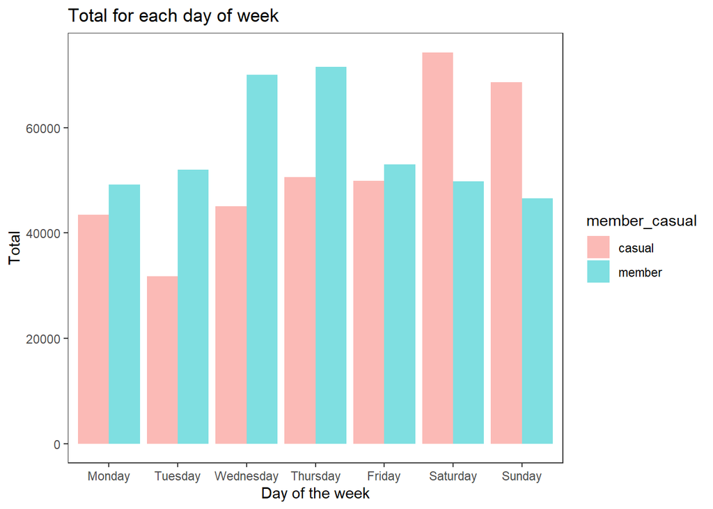

```r
sep_df %>%
  ggplot(aes(x = day_of_week9, fill = member_casual)) +
  geom_bar(position = "dodge", alpha = 0.5) +
  theme_bw() +
  theme(panel.grid.major = element_blank(),
        panel.grid.minor = element_blank()) +
  labs(title = "Total for each day of week",
       x = "Day of the week", y = "Total")
```

Member Users show higher patronage on Weekdays with Wednesdays and Thursdays being the most patronized while Casual Users had higher patronage on the weekend in general there are close patronage figures for both User groups

#### TOTAL BIKE TYPE USAGE FOR EACH DAY OF WEEK

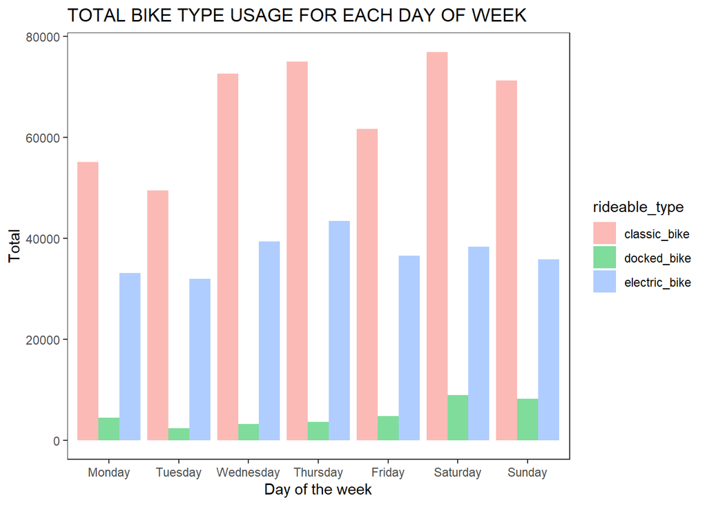

```r
sep_df %>%
  ggplot(aes(x = day_of_week9, fill = rideable_type)) +
  geom_bar(position = "dodge", alpha = 0.5) +
  theme_bw() +
  theme(panel.grid.major = element_blank(),
        panel.grid.minor = element_blank()) +
  labs(title = "TOTAL BIKE TYPE USAGE FOR EACH DAY OF WEEK",
       x = "Day of the week", y = "Total")
```

Classic bikes remain the most used bike type and then Electric bikes

#### TOTAL USAGE FOR EACH BIKE TYPE

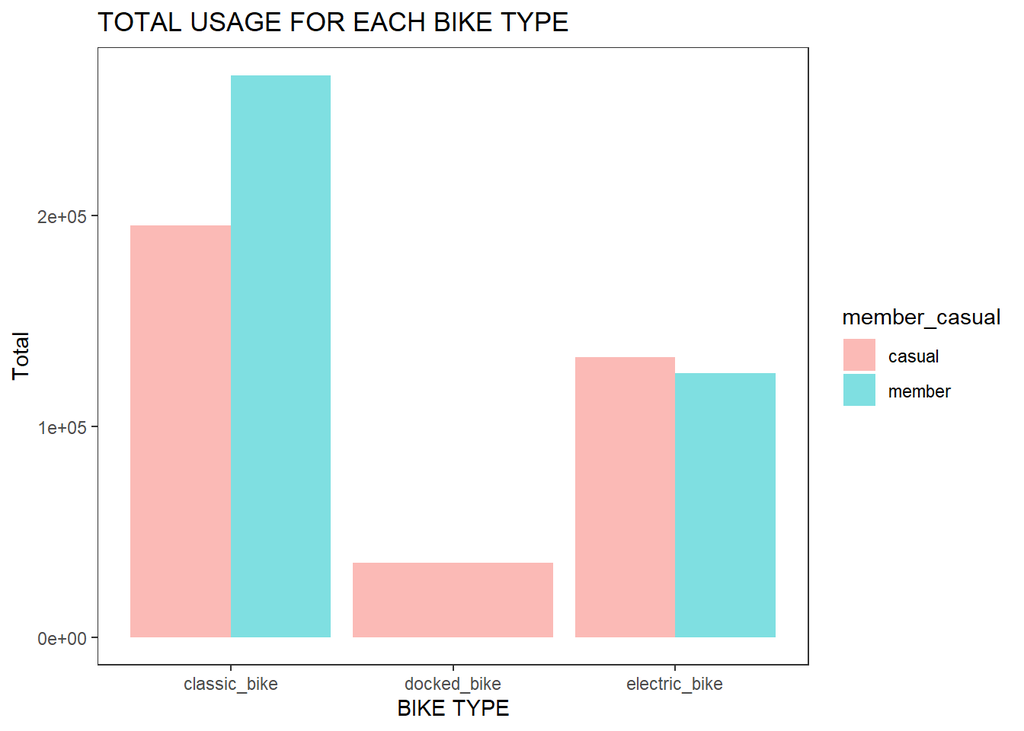

```r
sep_df %>%
  ggplot(aes(x = rideable_type, fill = member_casual)) +
  geom_bar(position = "dodge", alpha = 0.5) +
  theme_bw() +
  theme(panel.grid.major = element_blank(),
        panel.grid.minor = element_blank()) +
  labs(title = "TOTAL USAGE FOR EACH BIKE TYPE",
       x = "BIKE TYPE", y = "Total")
```

Member Users have the highest Usage of Classic bikes and then Causal Users Casual users have higher patronage of Electric bike types

#### AVERAGE RIDE DURATION FOR CUSTOMER TYPES

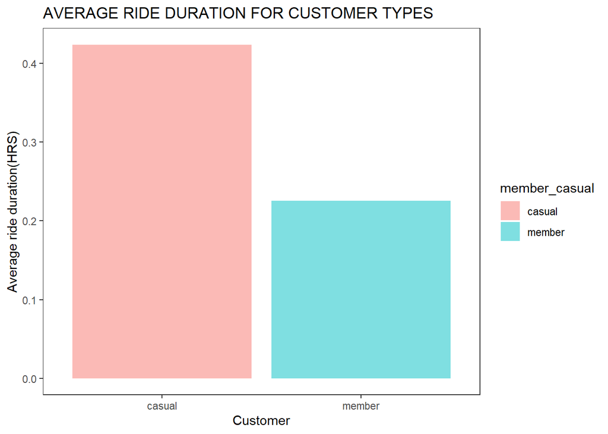

```r
ggplot(data = sep_df, aes(x = member_casual, ride_duration_hrs, fill = member_casual)) +
  geom_bar(position = "dodge", stat = "summary", fun = "mean",alpha = 0.5) +
  theme_bw() +
  theme(panel.grid.major = element_blank(),
        panel.grid.minor = element_blank()) +
  labs(title = "AVERAGE RIDE DURATION FOR CUSTOMER TYPES",
       x = "Customer", y = "Average ride duration(HRS)")
```

Higher Average duration for Casual users

#### AVERAGE RIDE DURATION FOR DIFFERENT WEEKDAYS BASED ON CUSTOMER TYPES

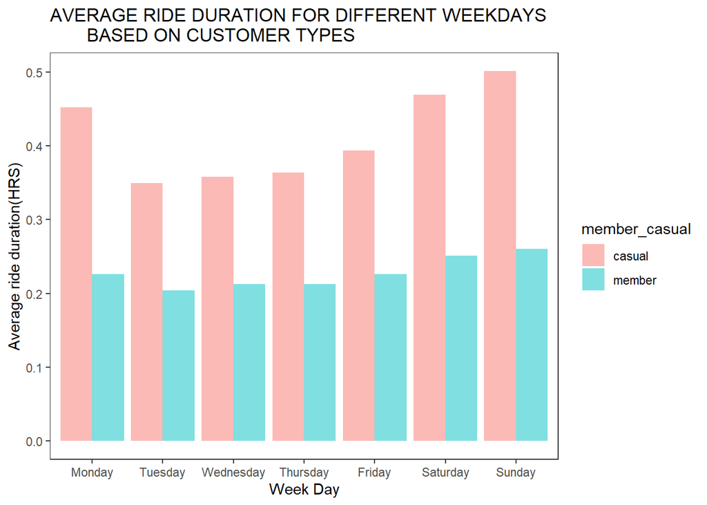

```r
ggplot(data = sep_df, aes(x = day_of_week9, ride_duration_hrs, fill = member_casual)) +
  geom_bar(position = "dodge", stat = "summary",
           fun = "mean",alpha = 0.5) +
  theme_bw() +
  theme(panel.grid.major = element_blank(),
        panel.grid.minor = element_blank()) +
  labs(title = "AVERAGE RIDE DURATION FOR DIFFERENT WEEKDAYS
       BASED ON CUSTOMER TYPES",
       x = "Week Day", y = "Average ride duration(HRS)")
```

Higher averages for Casual Users across all the days of the week

#### CUSTOMER AVERAGE RIDE DURATION FOR DIFFERENT BIKE TYPES

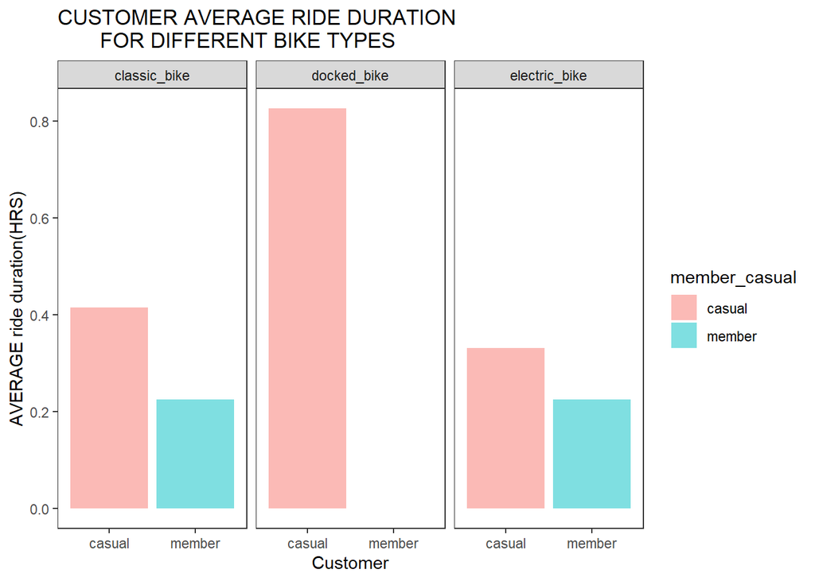

```r
ggplot(data = sep_df, aes(x = member_casual, ride_duration_hrs, fill = member_casual)) +
  geom_bar(position = "dodge", stat = "summary",
           fun = "mean",alpha = 0.5) +
  facet_wrap(~rideable_type) +
  theme_bw() +
  theme(panel.grid.major = element_blank(),
        panel.grid.minor = element_blank()) +
  labs(title = "CUSTOMER AVERAGE RIDE DURATION
       FOR DIFFERENT BIKE TYPES",
       x = "Customer", y = "AVERAGE ride duration(HRS)")
```

Docked bike type Show the highest average for casual customers

#### Max RIDE DURATION FOR CUSTOMER TYPES

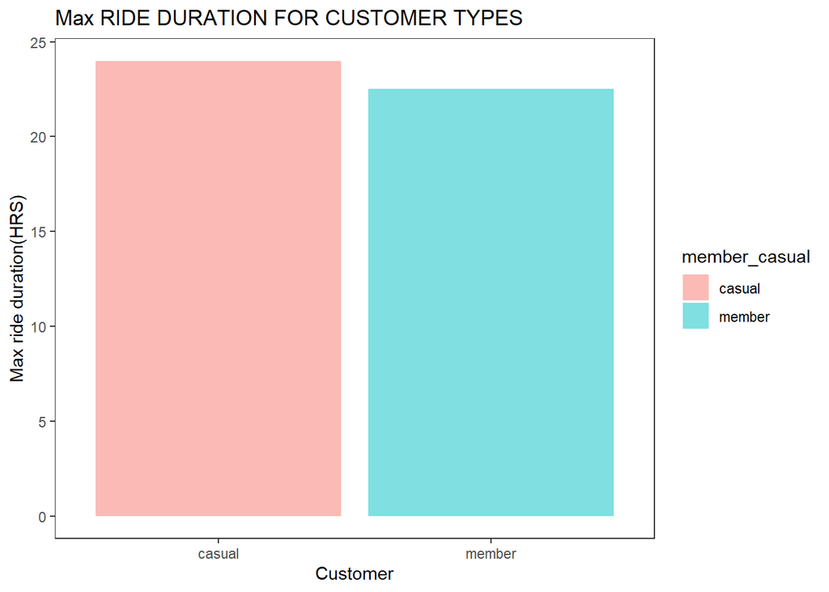

```r
ggplot(data = sep_df, aes(x = member_casual, ride_duration_hrs, fill = member_casual)) +
  geom_bar(position = "dodge", stat = "summary",
           fun = "max",alpha = 0.5) +
  theme_bw() +
  theme(panel.grid.major = element_blank(),
        panel.grid.minor = element_blank()) +
  labs(title = "Max RIDE DURATION FOR CUSTOMER TYPES",
       x = "Customer", y = "Max ride duration(HRS)")
```

Similar Maximum ride duration in the month of September

#### CUSTOMER Max RIDE DURATION FOR DIFFERENT BIKE TYPES

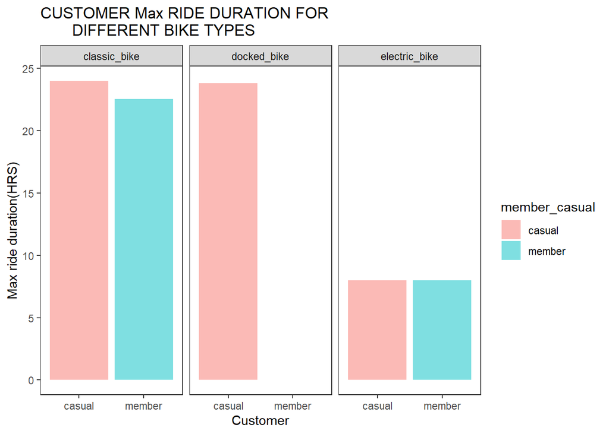

```r
ggplot(data = sep_df, aes(x = member_casual, ride_duration_hrs, fill = member_casual)) +
  geom_bar(position = "dodge", stat = "summary",
           fun = "max",alpha = 0.5) +
  facet_wrap(~rideable_type) +
  theme_bw() +
  theme(panel.grid.major = element_blank(),
        panel.grid.minor = element_blank()) +
  labs(title = "CUSTOMER Max RIDE DURATION FOR
       DIFFERENT BIKE TYPES",
       x = "Customer", y = "Max ride duration(HRS)")
```

Similar Maximum duration for both members and casual users for different bike types

### OCTOBER ANALYSIS

```r
oct_df <- read_csv("C:/Users/user/Desktop/Case Study/CASESTUDY CYCLING DATA/Cleaned Data/202110-divvy-tripdata_cleaned.csv")
head(oct_df)
```

```
## # A tibble: 6 x 18
##   ride_id        ridea~1 start~2 ended~3 ride_~4 ride_~5 day_o~6 start~7 start~8
##   <chr>          <chr>   <chr>   <chr>   <chr>   <time>  <chr>   <chr>   <chr>
## 1 620BC6107255B~ electr~ 10/22/~ 10/22/~ 10/22/~ 03'08"  Friday  Kingsb~ KA1503~
## 2 4471C70731AB2~ electr~ 10/21/~ 10/21/~ 10/21/~ 01'37"  Thursd~ <NA>    <NA>
## 3 26CA69D43D15E~ electr~ 10/16/~ 10/16/~ 10/16/~ 07'47"  Saturd~ <NA>    <NA>
## 4 362947F0437E1~ electr~ 10/16/~ 10/16/~ 10/16/~ 01'15"  Saturd~ <NA>    <NA>
## 5 BB731DE2F2EC5~ electr~ 10/20/~ 10/20/~ 10/20/~ 08'16"  Wednes~ <NA>    <NA>
## 6 7176307BBC097~ electr~ 10/21/~ 10/21/~ 10/21/~ 14'21"  Thursd~ <NA>    <NA>
## # ... with 9 more variables: end_station_name <chr>, end_station_id <chr>,
## #   start_lat <dbl>, start_lng <dbl>, end_lat <dbl>, end_lng <dbl>,
## #   member_casual <chr>, week_number <dbl>, ride_duration_hrs <dbl>, and
## #   abbreviated variable names 1: rideable_type, 2: started_at, 3: ended_at,
## #   4: ride_date, 5: ride_duration, 6: day_of_week, 7: start_station_name,
## #   8: start_station_id
## # i Use `colnames()` to see all variable names
```

#### Ordering the days of the week

```r
oct_df$day_of_week10 <- factor(oct_df$day_of_week, levels = c("Monday", "Tuesday", "Wednesday", "Thursday", "Friday", "Saturday", "Sunday"))
```

#### Total number of users for each Day of week

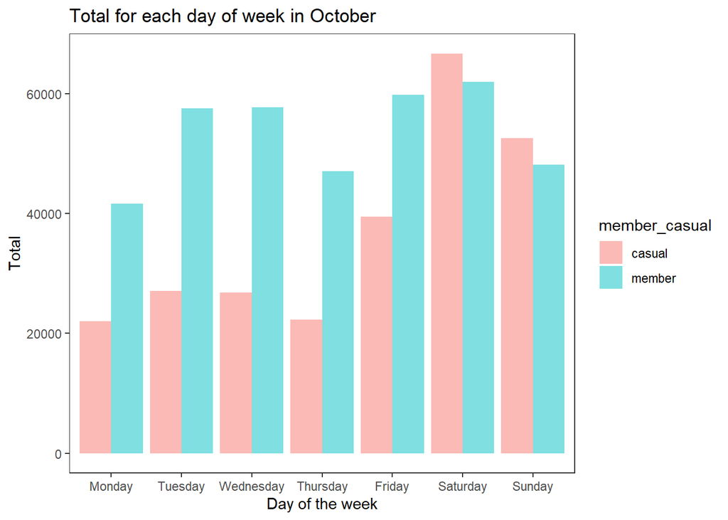

```r
oct_df %>%
  ggplot(aes(x = day_of_week10, fill = member_casual)) +
  geom_bar(position = "dodge", alpha = 0.5) +
  theme_bw() +
  theme(panel.grid.major = element_blank(),
        panel.grid.minor = element_blank()) +
  labs(title = "Total for each day of week in October",
       x = "Day of the week", y = "Total")
```

Consistent high patronage across all days for member users but lower patronage on the weekdays for Casual users and higher patronage on the weekends

#### TOTAL BIKE TYPE USAGE FOR EACH DAY OF WEEK

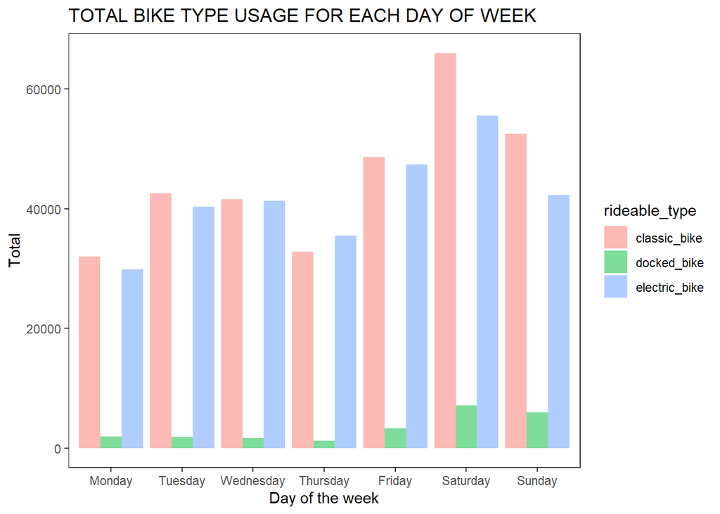

```r
oct_df %>%
  ggplot(aes(x = day_of_week10, fill = rideable_type)) +
  geom_bar(position = "dodge", alpha = 0.5) +
  theme_bw() +
  theme(panel.grid.major = element_blank(),
        panel.grid.minor = element_blank()) +
  labs(title = "TOTAL BIKE TYPE USAGE FOR EACH DAY OF WEEK",
       x = "Day of the week", y = "Total")
```

Close patronage numbers for both Classic and Electric bike types across all days of the week

#### TOTAL USAGE FOR EACH BIKE TYPE

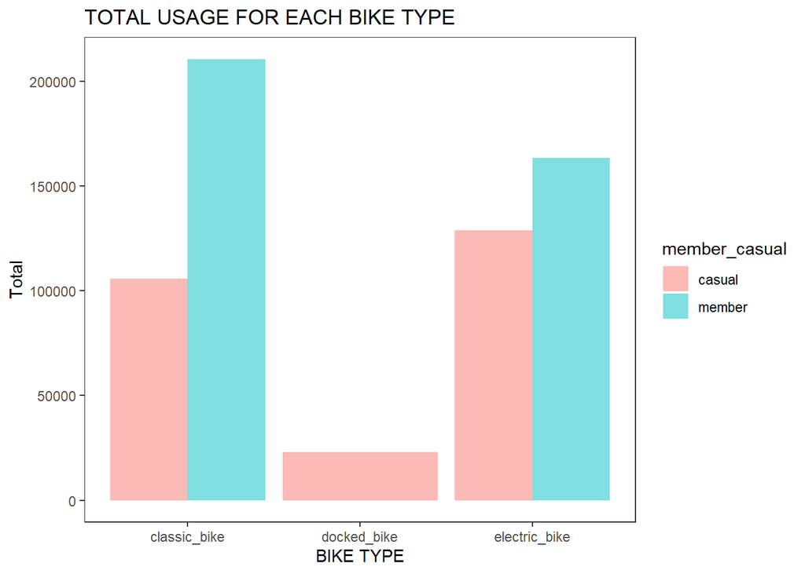

```r
oct_df %>%
  ggplot(aes(x = rideable_type, fill = member_casual)) +
  geom_bar(position = "dodge", alpha = 0.5) +
  theme_bw() +
  theme(panel.grid.major = element_blank(),
        panel.grid.minor = element_blank()) +
  labs(title = "TOTAL USAGE FOR EACH BIKE TYPE",
       x = "BIKE TYPE", y = "Total")
```

#### AVERAGE RIDE DURATION FOR CUSTOMER TYPES

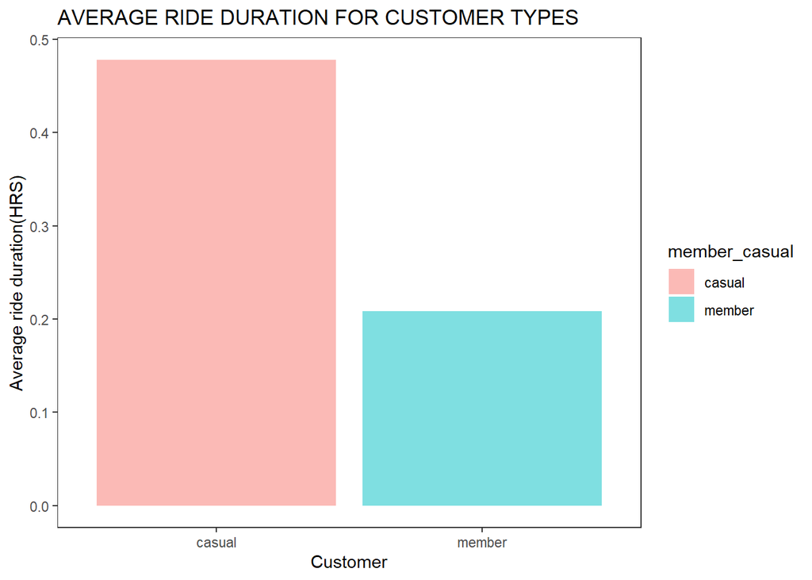

```r
ggplot(data = oct_df, aes(x = member_casual, ride_duration_hrs, fill = member_casual)) +
  geom_bar(position = "dodge", stat = "summary", fun = "mean",
           alpha = 0.5) +
  theme_bw() +
  theme(panel.grid.major = element_blank(),
        panel.grid.minor = element_blank()) +
  labs(title = "AVERAGE RIDE DURATION FOR CUSTOMER TYPES",
       x = "Customer", y = "Average ride duration(HRS)")
```

Average continuously higher for Casual users compared to Member Users

#### AVERAGE RIDE DURATION FOR DIFFERENT WEEKDAYS BASED ON CUSTOMER TYPES

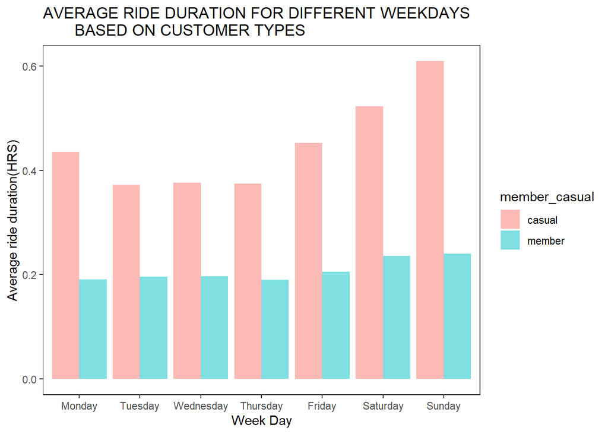

```r
ggplot(data = oct_df, aes(x = day_of_week10, ride_duration_hrs, fill = member_casual)) +
  geom_bar(position = "dodge", stat = "summary", fun = "mean",
           alpha = 0.5) +
  theme_bw() +
  theme(panel.grid.major = element_blank(),
        panel.grid.minor = element_blank()) +
  labs(title = "AVERAGE RIDE DURATION FOR DIFFERENT WEEKDAYS
       BASED ON CUSTOMER TYPES",
       x = "Week Day", y = "Average ride duration(HRS)")
```

Casual users Higher averages across all days with the weekend having the highest

#### CUSTOMER AVERAGE RIDE DURATION FOR DIFFERENT BIKE TYPES

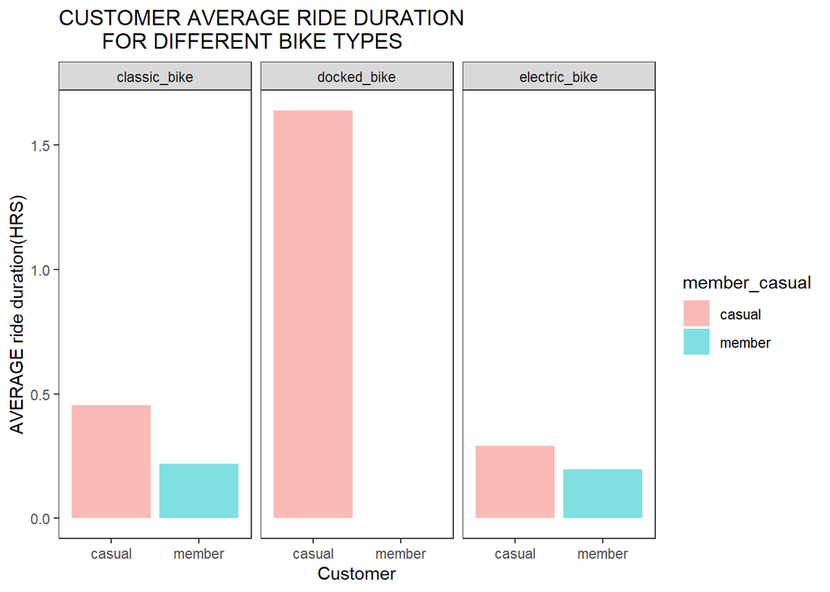

```r
ggplot(data = oct_df, aes(x = member_casual, ride_duration_hrs, fill = member_casual)) +
  geom_bar(position = "dodge", stat = "summary", fun = "mean",
           alpha = 0.5) +
  facet_wrap(~rideable_type) +
  theme_bw() +
  theme(panel.grid.major = element_blank(),
        panel.grid.minor = element_blank()) +
  labs(title = "CUSTOMER AVERAGE RIDE DURATION
       FOR DIFFERENT BIKE TYPES",
       x = "Customer", y = "AVERAGE ride duration(HRS)")
```

#### Max RIDE DURATION FOR CUSTOMER TYPES

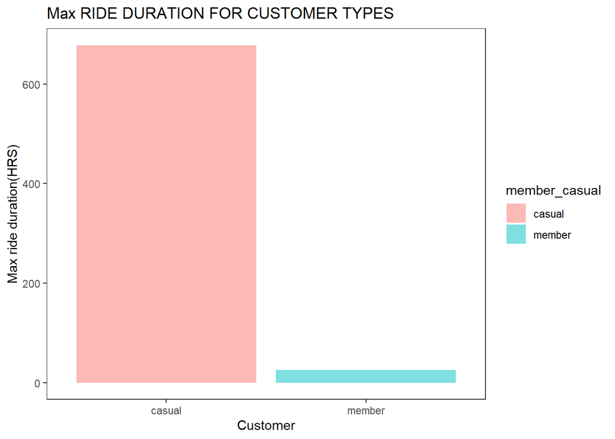

```r
ggplot(data = oct_df, aes(x = member_casual, ride_duration_hrs, fill = member_casual)) +
  geom_bar(position = "dodge", stat = "summary", fun = "max",
           alpha = 0.5) +
  theme_bw() +
  theme(panel.grid.major = element_blank(),
        panel.grid.minor = element_blank()) +
  labs(title = "Max RIDE DURATION FOR CUSTOMER TYPES",
       x = "Customer", y = "Max ride duration(HRS)")
```

Casual Users continue to have higher Maximum duration

#### CUSTOMER Max RIDE DURATION FOR DIFFERENT BIKE TYPES

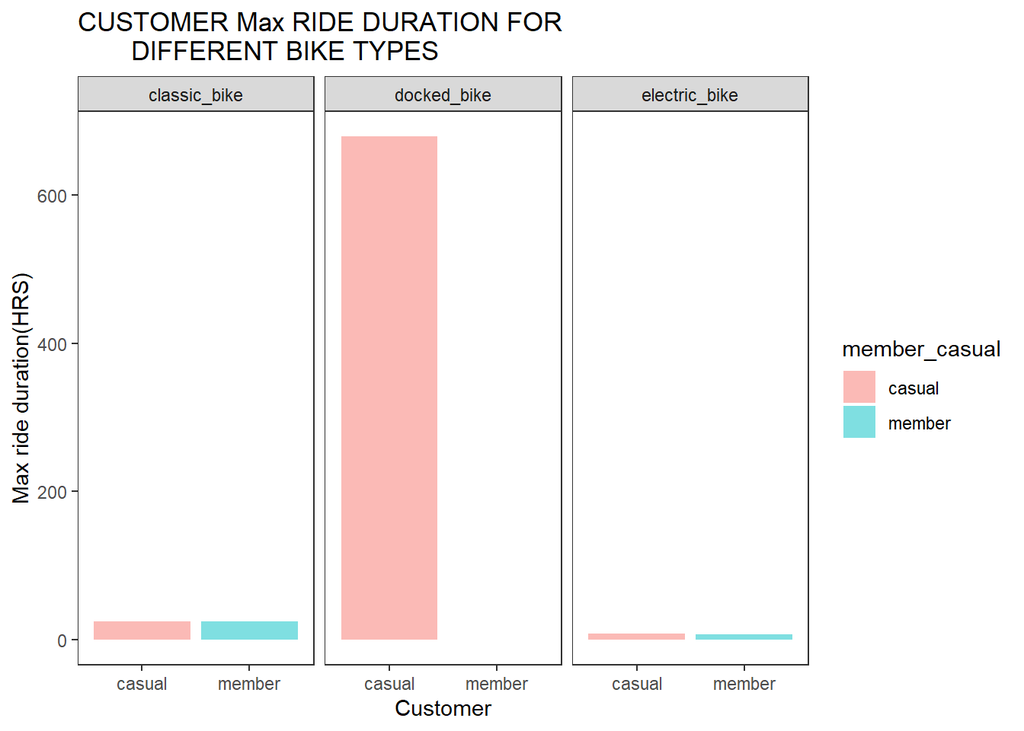

```r
ggplot(data = oct_df, aes(x = member_casual, ride_duration_hrs, fill = member_casual)) +
  geom_bar(position = "dodge", stat = "summary", fun = "max",
           alpha = 0.5) +
  facet_wrap(~rideable_type) +
  theme_bw() +
  theme(panel.grid.major = element_blank(),
        panel.grid.minor = element_blank()) +
  labs(title = "CUSTOMER Max RIDE DURATION FOR
       DIFFERENT BIKE TYPES",
       x = "Customer", y = "Max ride duration(HRS)")
```

### NOVEMBER ANALYSIS

```r
nov_df <- read_csv("C:/Users/user/Desktop/Case Study/CASESTUDY CYCLING DATA/Cleaned Data/202111-divvy-tripdata_cleaned.csv")
head(nov_df)
```

```
## # A tibble: 6 x 18
##   ride_id        ridea~1 start~2 ended~3 ride_~4 ride_~5 day_o~6 start~7 start~8
##   <chr>          <chr>   <chr>   <chr>   <chr>   <time>  <chr>   <chr>   <chr>
## 1 7C00A93E10556~ electr~ 11/27/~ 11/27/~ 11/27/~ 19'00"  Saturd~ <NA>    <NA>
## 2 90854840DFD50~ electr~ 11/27/~ 11/27/~ 11/27/~ 17'45"  Saturd~ <NA>    <NA>
## 3 0A7D10CDD1440~ electr~ 11/26/~ 11/26/~ 11/26/~ 02'22"  Friday  <NA>    <NA>
## 4 2F3BE33085BCF~ electr~ 11/27/~ 11/27/~ 11/27/~ 05'01"  Saturd~ <NA>    <NA>
## 5 D67B4781A1992~ electr~ 11/26/~ 11/26/~ 11/26/~ 21'13"  Friday  <NA>    <NA>
## 6 02F85C2C3C5F7~ electr~ 11/26/~ 11/26/~ 11/26/~ 18'42"  Friday  Michig~ 13042
## # ... with 9 more variables: end_station_name <chr>, end_station_id <chr>,
## #   start_lat <dbl>, start_lng <dbl>, end_lat <dbl>, end_lng <dbl>,
## #   member_casual <chr>, week_number <dbl>, ride_duration_hrs <dbl>, and
## #   abbreviated variable names 1: rideable_type, 2: started_at, 3: ended_at,
## #   4: ride_date, 5: ride_duration, 6: day_of_week, 7: start_station_name,
## #   8: start_station_id
## # i Use `colnames()` to see all variable names
```

#### Ordering the days of the week

```r
nov_df$day_of_week11 <- factor(nov_df$day_of_week, levels = c("Monday", "Tuesday", "Wednesday", "Thursday", "Friday", "Saturday", "Sunday"))
```

#### Total for each day of Day of week

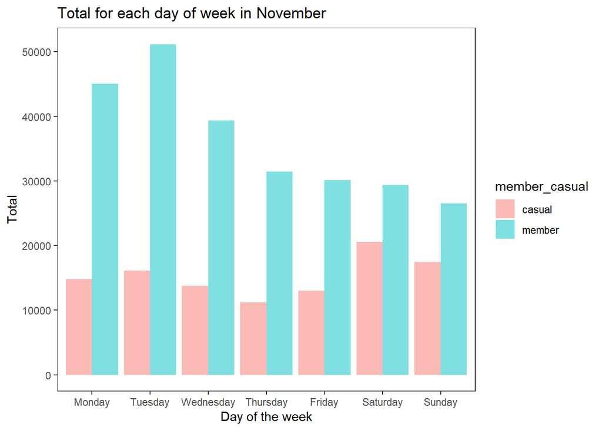

```r
nov_df %>%
  ggplot(aes(x = day_of_week11, fill = member_casual)) +
  geom_bar(position = "dodge", alpha = 0.5) +
  theme_bw() +
  theme(panel.grid.major = element_blank(),
        panel.grid.minor = element_blank()) +
  labs(title = "Total for each day of week in November",
       x = "Day of the week", y = "Total")
```

Member users have the highest patronage across all days with gradual decline towards the weekend while Casual users show consistently low patronage

#### TOTAL BIKE TYPE USAGE FOR EACH DAY OF WEEK

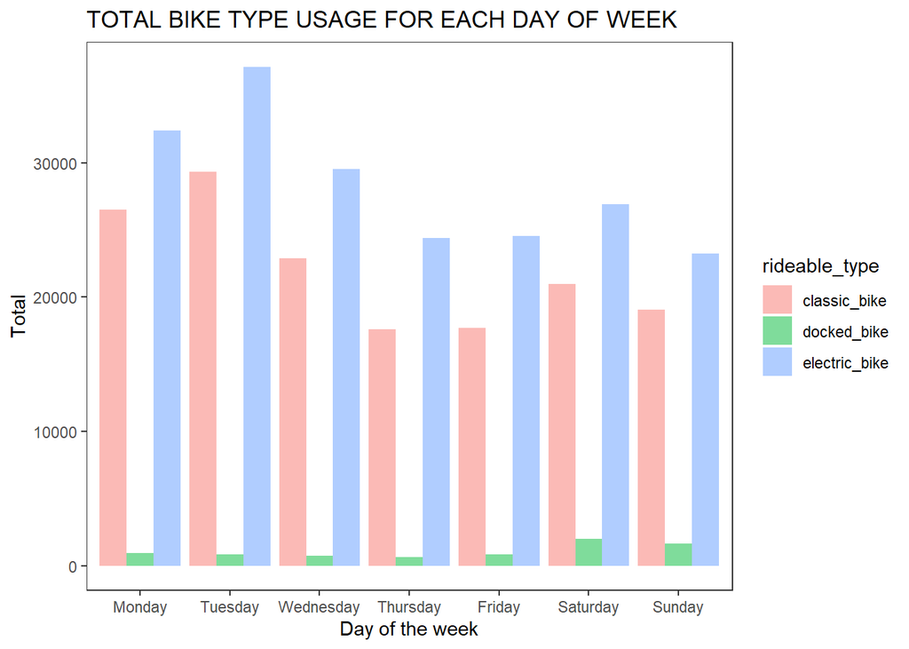

```r
nov_df %>%
  ggplot(aes(x = day_of_week11, fill = rideable_type)) +
  geom_bar(position = "dodge", alpha = 0.5) +
  theme_bw() +
  theme(panel.grid.major = element_blank(),
        panel.grid.minor = element_blank()) +
  labs(title = "TOTAL BIKE TYPE USAGE FOR EACH DAY OF WEEK",
       x = "Day of the week", y = "Total")
```

Electric bike type usage surpass Classic bike usage still showing a gradual decline towards the end of the week

#### TOTAL USAGE FOR EACH BIKE TYPE

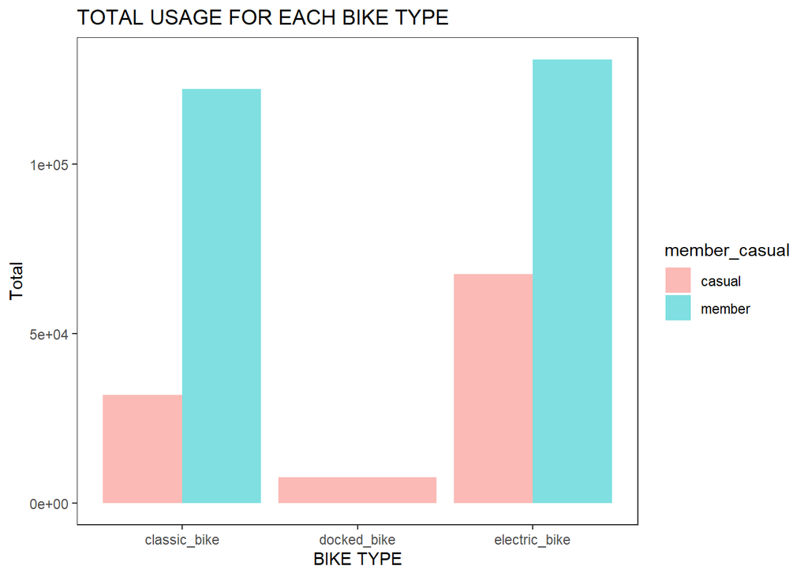

```r
nov_df %>%
  ggplot(aes(x = rideable_type, fill = member_casual)) +
  geom_bar(position = "dodge", alpha = 0.5) +
  theme_bw() +
  theme(panel.grid.major = element_blank(),
        panel.grid.minor = element_blank()) +
  labs(title = "TOTAL USAGE FOR EACH BIKE TYPE",
       x = "BIKE TYPE", y = "Total")
```

#### AVERAGE RIDE DURATION FOR CUSTOMER TYPES

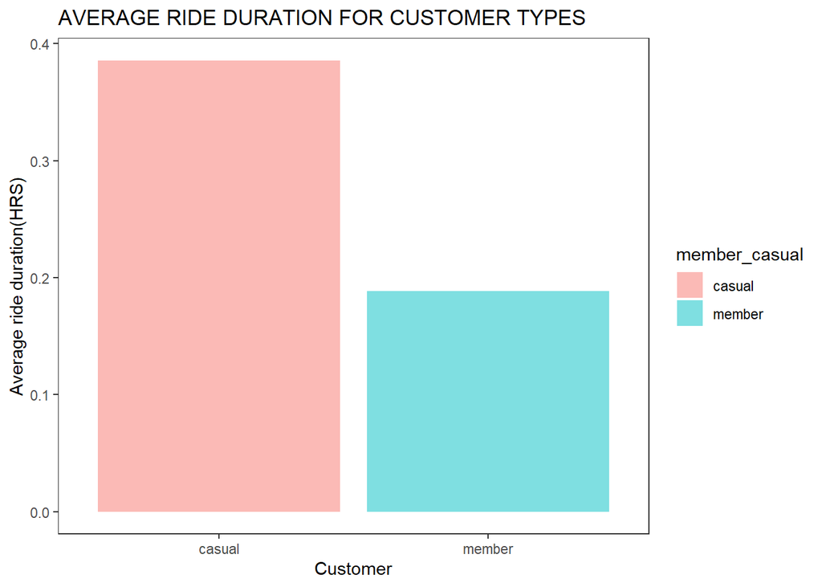

```r
ggplot(data = nov_df, aes(x = member_casual, ride_duration_hrs, fill = member_casual)) +
  geom_bar(position = "dodge", stat = "summary", fun = "mean",
           alpha = 0.5) +
  theme_bw() +
  theme(panel.grid.major = element_blank(),
        panel.grid.minor = element_blank()) +
  labs(title = "AVERAGE RIDE DURATION FOR CUSTOMER TYPES",
       x = "Customer", y = "Average ride duration(HRS)")
```

Higher averages for Casual users compared to Member users

#### AVERAGE RIDE DURATION FOR DIFFERENT WEEKDAYS BASED ON CUSTOMER TYPES

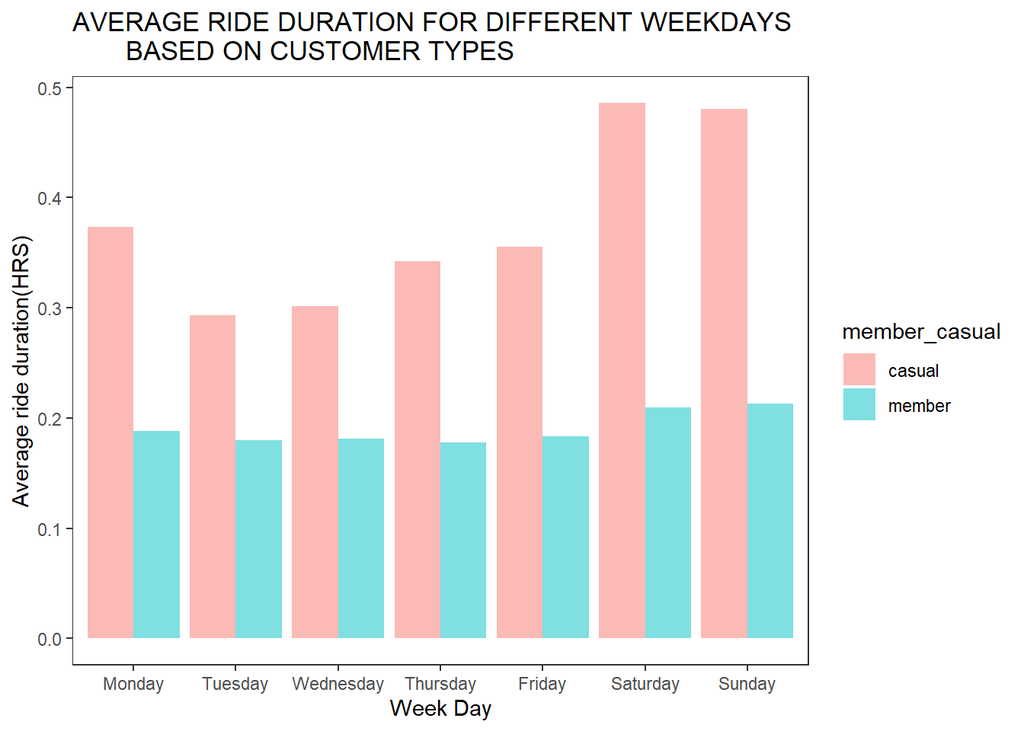

```r
ggplot(data = nov_df, aes(x = day_of_week11, ride_duration_hrs, fill = member_casual)) +
  geom_bar(position = "dodge", stat = "summary", fun = "mean",
           alpha = 0.5) +
  theme_bw() +
  theme(panel.grid.major = element_blank(),
        panel.grid.minor = element_blank()) +
  labs(title = "AVERAGE RIDE DURATION FOR DIFFERENT WEEKDAYS
       BASED ON CUSTOMER TYPES",
       x = "Week Day", y = "Average ride duration(HRS)")
```

Casual Users continue to show higher averages across all days

#### CUSTOMER AVERAGE RIDE DURATION FOR DIFFERENT BIKE TYPES

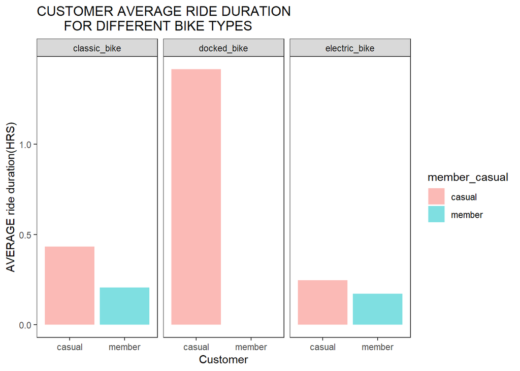

```r
ggplot(data = nov_df, aes(x = member_casual, ride_duration_hrs, fill = member_casual)) +
  geom_bar(position = "dodge", stat = "summary", fun = "mean",
           alpha = 0.5) +
  facet_wrap(~rideable_type) +
  theme_bw() +
  theme(panel.grid.major = element_blank(),
        panel.grid.minor = element_blank()) +
  labs(title = "CUSTOMER AVERAGE RIDE DURATION
       FOR DIFFERENT BIKE TYPES",
       x = "Customer", y = "AVERAGE ride duration(HRS)")
```

Higher ride duration for Docked bikes and Casual users ride bikes for longest durations

#### Max RIDE DURATION FOR CUSTOMER TYPES

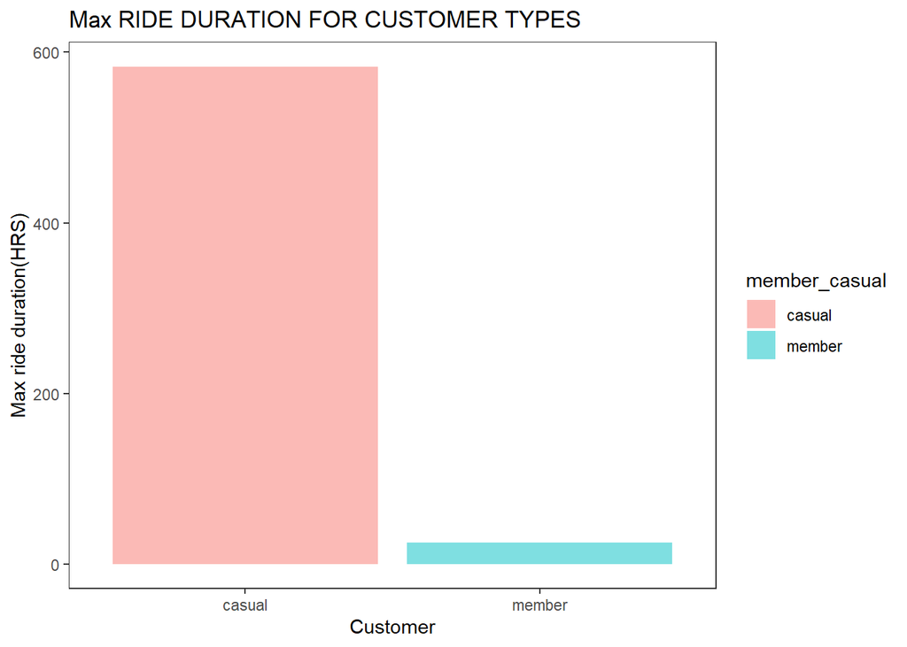

```r
ggplot(data = nov_df, aes(x = member_casual, ride_duration_hrs, fill = member_casual)) +
  geom_bar(position = "dodge", stat = "summary", fun = "max",
           alpha = 0.5) +
  theme_bw() +
  theme(panel.grid.major = element_blank(),
        panel.grid.minor = element_blank()) +
  labs(title = "Max RIDE DURATION FOR CUSTOMER TYPES",
       x = "Customer", y = "Max ride duration(HRS)")
```

Casual users continue to show higher Max ride duration

#### CUSTOMER Max RIDE DURATION FOR DIFFERENT BIKE TYPES

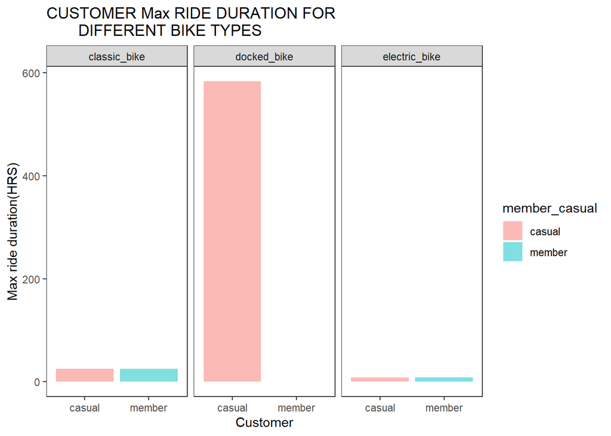

```r
ggplot(data = nov_df, aes(x = member_casual, ride_duration_hrs, fill = member_casual)) +
  geom_bar(position = "dodge", stat = "summary", fun = "max",
           alpha = 0.5) +
  facet_wrap(~rideable_type) +
  theme_bw() +
  theme(panel.grid.major = element_blank(),
        panel.grid.minor = element_blank()) +
  labs(title = "CUSTOMER Max RIDE DURATION FOR
       DIFFERENT BIKE TYPES",
       x = "Customer", y = "Max ride duration(HRS)")
```

### DECEMBER ANALYSIS

```r
dec_df <- read_csv("C:/Users/user/Desktop/Case Study/CASESTUDY CYCLING DATA/Cleaned Data/202112-divvy-tripdata_cleaned.csv")
head(dec_df)
```

```
## # A tibble: 6 x 18
##   ride_id        ridea~1 start~2 ended~3 ride_~4 ride_~5 day_o~6 start~7 start~8
##   <chr>          <chr>   <chr>   <chr>   <chr>   <time>  <chr>   <chr>   <chr>
## 1 46F8167220E44~ electr~ 12/7/2~ 12/7/2~ 12/7/2~ 07'35"  Tuesday Laflin~ 13307
## 2 73A77762838B3~ electr~ 12/11/~ 12/11/~ 12/11/~ 26'54"  Saturd~ LaSall~ KP1705~
## 3 4CF42452054F5~ electr~ 12/15/~ 12/15/~ 12/15/~ 12'46"  Wednes~ Halste~ KA1504~
## 4 3278BA87BF698~ classi~ 12/26/~ 12/26/~ 12/26/~ 14'43"  Sunday  Halste~ KA1504~
## 5 6FF54232576A3~ electr~ 12/30/~ 12/30/~ 12/30/~ 20'16"  Thursd~ Leavit~ 18058
## 6 93E8D79490E3A~ classi~ 12/1/2~ 12/1/2~ 12/1/2~ 09'27"  Wednes~ Wabash~ SL-012
## # ... with 9 more variables: end_station_name <chr>, end_station_id <chr>,
## #   start_lat <dbl>, start_lng <dbl>, end_lat <dbl>, end_lng <dbl>,
## #   member_casual <chr>, week_number <dbl>, ride_duration_hrs <dbl>, and
## #   abbreviated variable names 1: rideable_type, 2: started_at, 3: ended_at,
## #   4: ride_date, 5: ride_duration, 6: day_of_week, 7: start_station_name,
## #   8: start_station_id
## # i Use `colnames()` to see all variable names
```

#### Ordering the days of the week

```r
dec_df$day_of_week12 <- factor(dec_df$day_of_week, levels = c("Monday", "Tuesday", "Wednesday", "Thursday", "Friday", "Saturday", "Sunday"))
```

#### Total number of users for each Day of Week

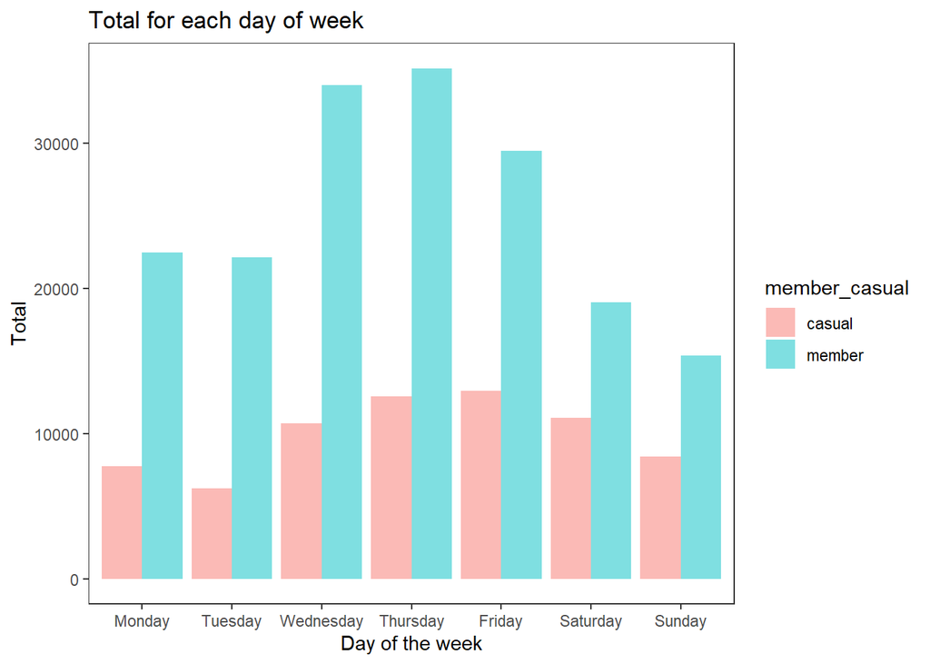

```r
dec_df %>%
  ggplot(aes(x = day_of_week12, fill = member_casual)) +
  geom_bar(position = "dodge", alpha = 0.5) +
  theme_bw() +
  theme(panel.grid.major = element_blank(),
        panel.grid.minor = element_blank()) +
  labs(title = "Total for each day of week",
       x = "Day of the week", y = "Total")
```

Member users have the highest patronage across all days with the Middle of the week recording the highest patronage while Casual users recorded low patronage

#### TOTAL BIKE TYPE USAGE FOR EACH DAY OF WEEK

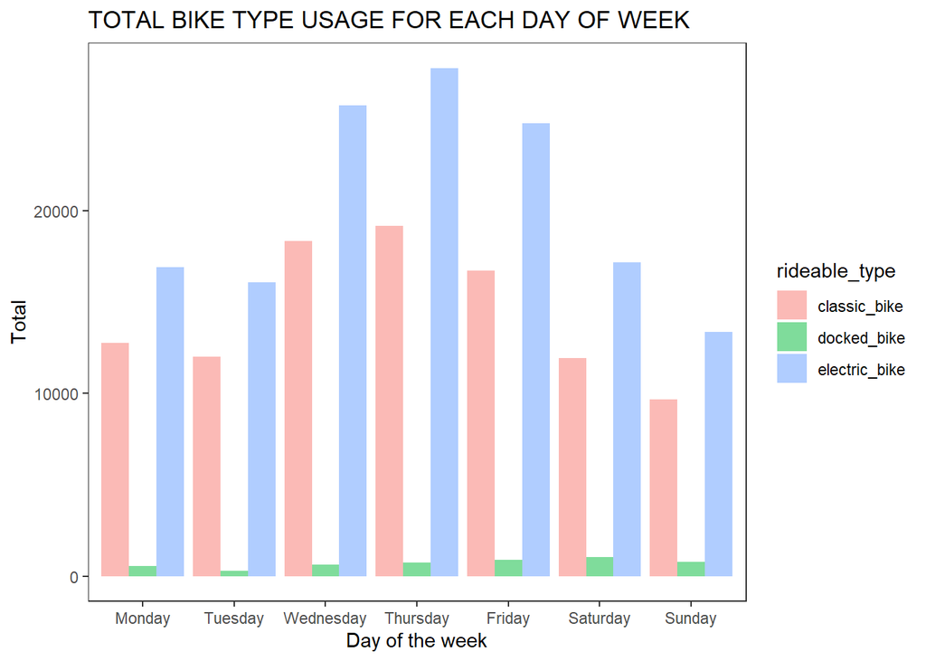

```r
dec_df %>%
  ggplot(aes(x = day_of_week12, fill = rideable_type)) +
  geom_bar(position = "dodge", alpha = 0.5) +
  theme_bw() +
  theme(panel.grid.major = element_blank(),
        panel.grid.minor = element_blank()) +
  labs(title = "TOTAL BIKE TYPE USAGE FOR EACH DAY OF WEEK",
       x = "Day of the week", y = "Total")
```

Highest patronage recorded from Electric bikes and then Classic bikes

#### TOTAL USAGE FOR EACH BIKE TYPE

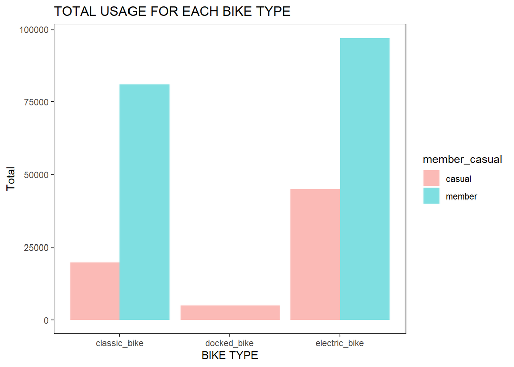

```r
dec_df %>%
  ggplot(aes(x = rideable_type, fill = member_casual)) +
  geom_bar(position = "dodge", alpha = 0.5) +
  theme_bw() +
  theme(panel.grid.major = element_blank(),
        panel.grid.minor = element_blank()) +
  labs(title = "TOTAL USAGE FOR EACH BIKE TYPE",
       x = "BIKE TYPE", y = "Total")
```

Highest patronage recorded for members using Electric Bike types and the classic similar trend seen with casual users

#### AVERAGE RIDE DURATION FOR CUSTOMER TYPES

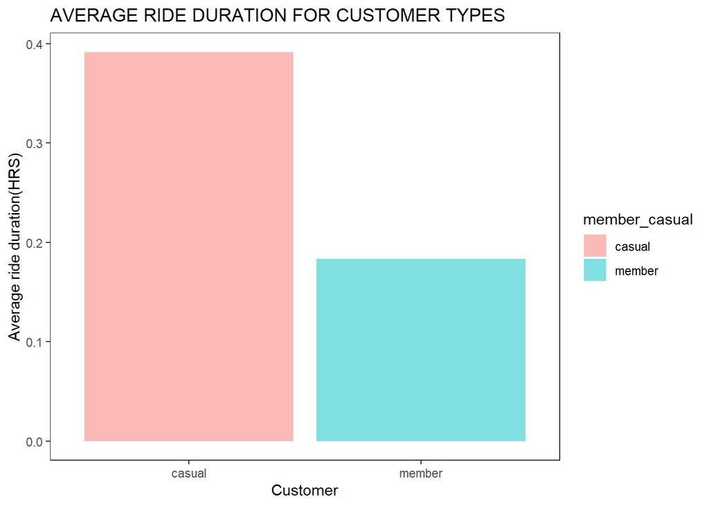

```r
ggplot(data = dec_df, aes(x = member_casual, ride_duration_hrs, fill = member_casual)) +
  geom_bar(position = "dodge", stat = "summary", fun = "mean",
           alpha = 0.5) +
  theme_bw() +
  theme(panel.grid.major = element_blank(),
        panel.grid.minor = element_blank()) +
  labs(title = "AVERAGE RIDE DURATION FOR CUSTOMER TYPES",
       x = "Customer", y = "Average ride duration(HRS)")
```

Higher ride average for causal users compared to Member users

#### AVERAGE RIDE DURATION FOR DIFFERENT WEEKDAYS BASED ON CUSTOMER TYPES

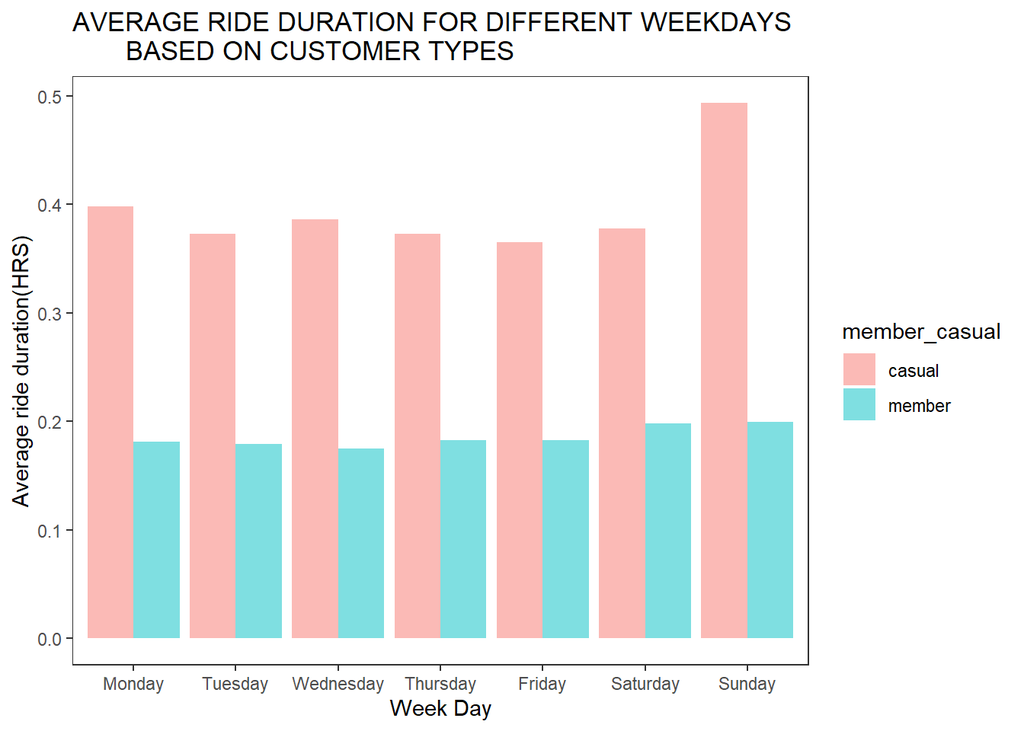

```r
ggplot(data = dec_df, aes(x = day_of_week12, ride_duration_hrs, fill = member_casual)) +
  geom_bar(position = "dodge", stat = "summary", fun = "mean",
           alpha = 0.5) +
  theme_bw() +
  theme(panel.grid.major = element_blank(),
        panel.grid.minor = element_blank()) +
  labs(title = "AVERAGE RIDE DURATION FOR DIFFERENT WEEKDAYS
       BASED ON CUSTOMER TYPES",
       x = "Week Day", y = "Average ride duration(HRS)")
```

Higher average across all days for casual users

#### CUSTOMER AVERAGE RIDE DURATION FOR DIFFERENT BIKE TYPES

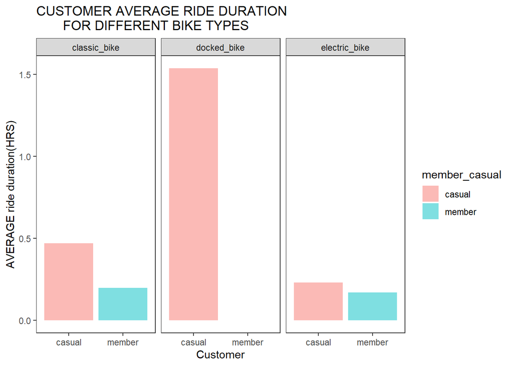

```r
ggplot(data = dec_df, aes(x = member_casual, ride_duration_hrs, fill = member_casual)) +
  geom_bar(position = "dodge", stat = "summary", fun = "mean",
           alpha = 0.5) +
  facet_wrap(~rideable_type) +
  theme_bw() +
  theme(panel.grid.major = element_blank(),
        panel.grid.minor = element_blank()) +
  labs(title = "CUSTOMER AVERAGE RIDE DURATION
       FOR DIFFERENT BIKE TYPES",
       x = "Customer", y = "AVERAGE ride duration(HRS)")
```

Docked types continue to record the highest averages

#### Max RIDE DURATION FOR CUSTOMER TYPES

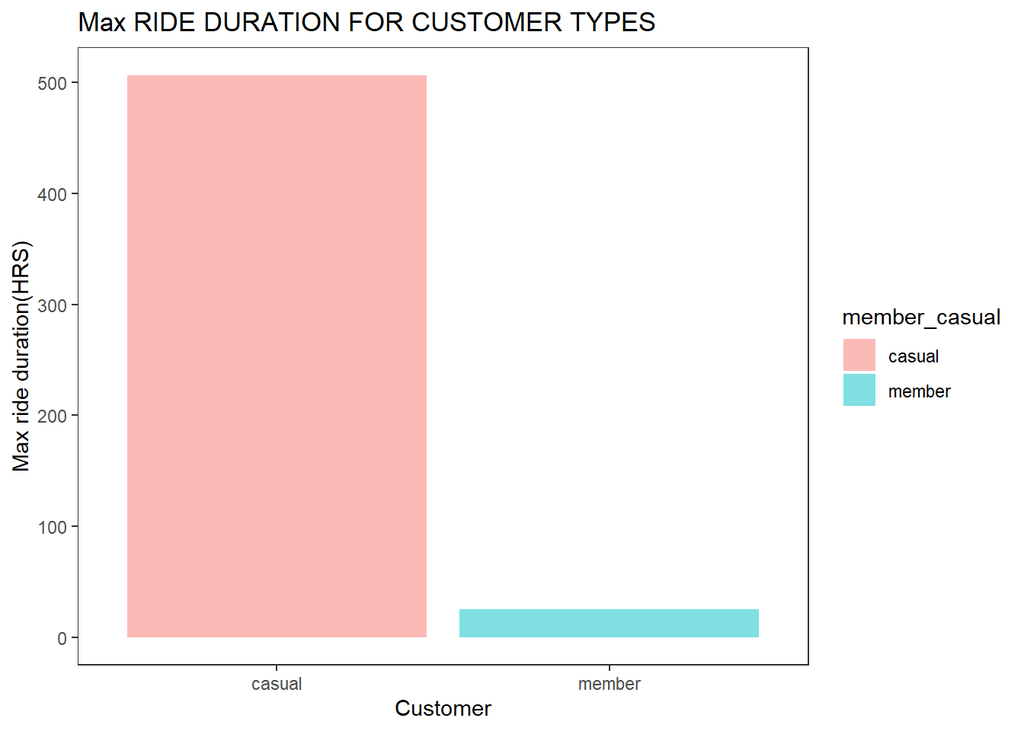

```r
ggplot(data = dec_df, aes(x = member_casual, ride_duration_hrs, fill = member_casual)) +
  geom_bar(position = "dodge", stat = "summary", fun = "max",
           alpha = 0.5) +
  theme_bw() +
  theme(panel.grid.major = element_blank(),
        panel.grid.minor = element_blank()) +
  labs(title = "Max RIDE DURATION FOR CUSTOMER TYPES",
       x = "Customer", y = "Max ride duration(HRS)")
```

#### CUSTOMER Max RIDE DURATION FOR DIFFERENT BIKE TYPES

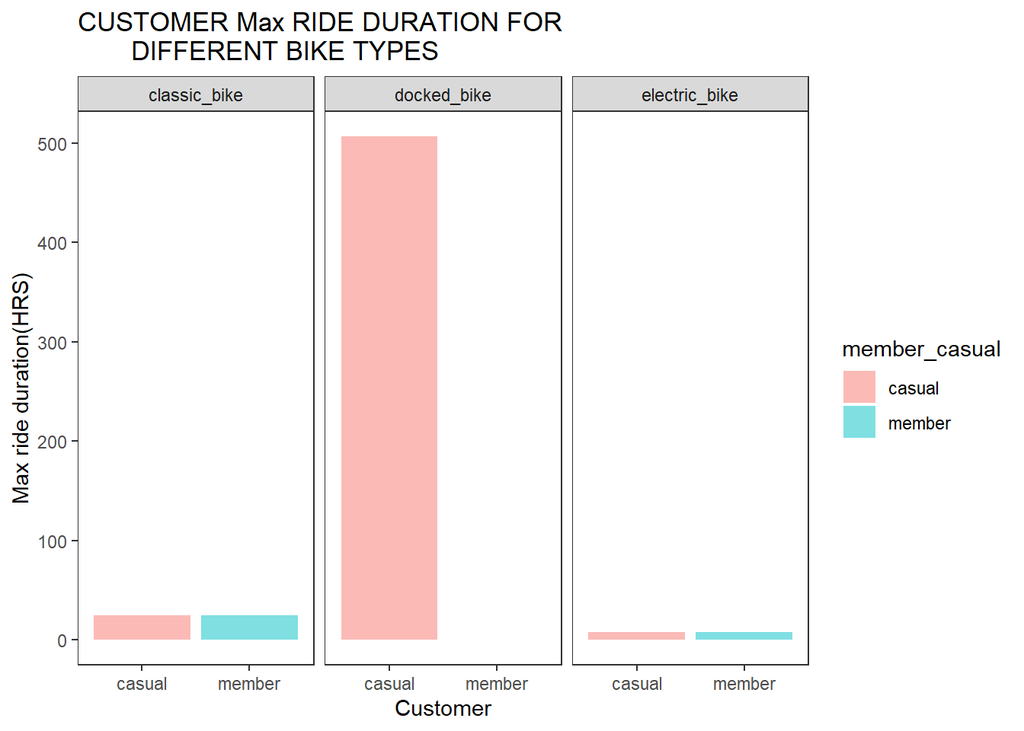

```r
ggplot(data = dec_df, aes(x = member_casual, ride_duration_hrs, fill = member_casual)) +
  geom_bar(position = "dodge", stat = "summary", fun = "max",
           alpha = 0.5) +
  facet_wrap(~rideable_type) +
  theme_bw() +
  theme(panel.grid.major = element_blank(),
        panel.grid.minor = element_blank()) +
  labs(title = "CUSTOMER Max RIDE DURATION FOR
       DIFFERENT BIKE TYPES",
       x = "Customer", y = "Max ride duration(HRS)")
```

### OVER VIEW OF THE ENTIRE YEAR

```r
usertype_df <- read_csv("C:/Users/user/Desktop/Case Study/CASESTUDY CYCLING DATA/Cleaned Data/customer_year_stat.csv")
head(usertype_df)
```

```
## # A tibble: 6 x 8
##   member_casual avg_ride_durat~1 max_r~2 min_r~3 total~4 ride_~5 max_r~6 max_r~7
##   <chr>                    <dbl>   <dbl>   <dbl>   <dbl> <chr>     <dbl>   <dbl>
## 1 casual                    38.0  47777.    0.02  136590 April     796.    796.
## 2 member                    14.7   1500.    0.02  200602 April      25.0    25.0
## 3 casual                    28.8  41629.    0.02  412608 August    694.    694.
## 4 member                    14.1   1500.    0.02  391637 August     25.0    25.0
## 5 casual                    23.5  30401.    0.02   69729 Decemb~   507.    507.
## 6 member                    11.0   1500.    0.02  177790 Decemb~    25.0    25.0
## # ... with abbreviated variable names 1: avg_ride_duration,
## #   2: max_ride_duration, 3: min_ride_duration, 4: total_rides, 5: ride_month,
## #   6: `max_ride_duration(hrs)`, 7: max_ride_duration_hrs
```

#### TOTAL PATRONGE FOR CUSTOMER TYPES

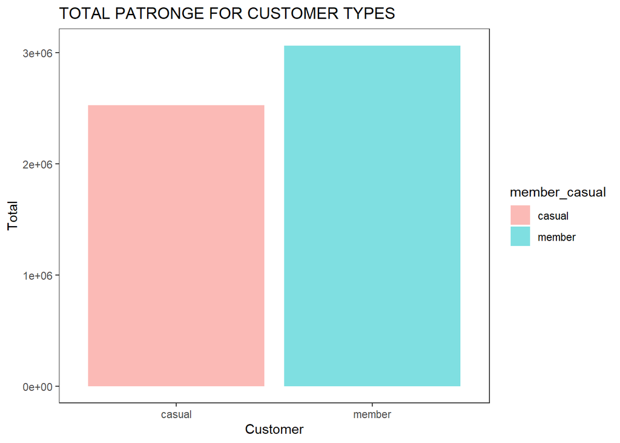

```r
usertype_df %>%
  ggplot(aes(x = member_casual, total_rides, fill = member_casual)) +
  geom_bar(position = "dodge", stat = "summary", fun = "sum",
           alpha = 0.5) +
  theme_bw() +
  theme(panel.grid.major = element_blank(),
        panel.grid.minor = element_blank()) +
  labs(title = "TOTAL PATRONGE FOR CUSTOMER TYPES",
       x = "Customer", y = "Total")
```

Members had a higher patronage but Casual users had a 45% patronage which shows a huge target market and potential Member base.

#### AVERAGE RIDE DURATION FOR CUSTOMER TYPES

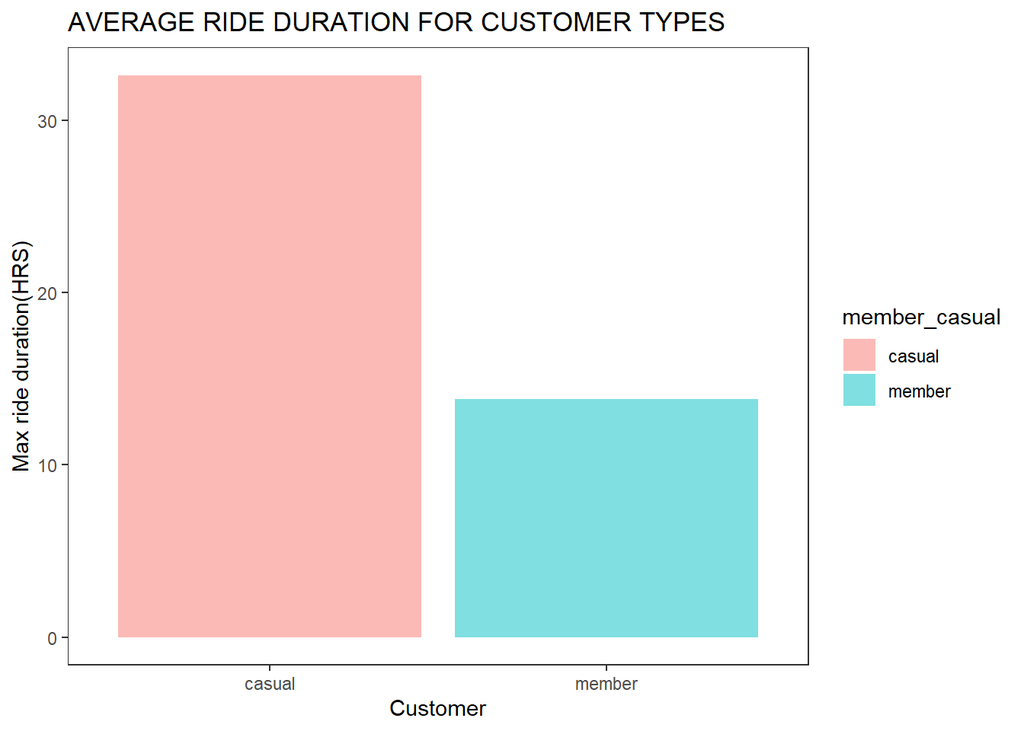

```r
usertype_df %>%
  ggplot(aes(x = member_casual, avg_ride_duration, fill = member_casual)) +
  geom_bar(position = "dodge", stat = "summary", fun = "mean",
           alpha = 0.5) +
  theme_bw() +
  theme(panel.grid.major = element_blank(),
        panel.grid.minor = element_blank()) +
  labs(title = "AVERAGE RIDE DURATION FOR CUSTOMER TYPES",
       x = "Customer", y = "Max ride duration(HRS)")
```

Casual Users had the highest average duration which means on average they rode the bikes for longest periods and longer times

#### MAX RIDE DURATION FOR CUSTOMER TYPES

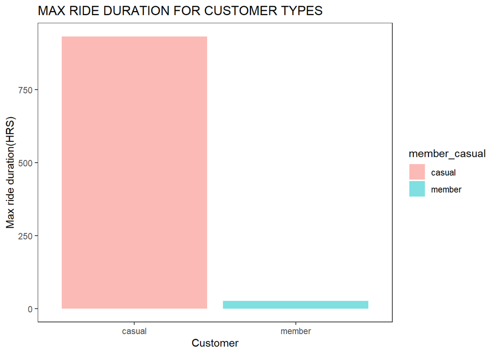

```r
usertype_df %>%
  ggplot(aes(x = member_casual, max_ride_duration_hrs, fill = member_casual)) +
  geom_bar(position = "dodge", stat = "summary", fun = "max",
           alpha = 0.5) +
  theme_bw() +
  theme(panel.grid.major = element_blank(),
        panel.grid.minor = element_blank()) +
  labs(title = "MAX RIDE DURATION FOR CUSTOMER TYPES",
       x = "Customer", y = "Max ride duration(HRS)")
```

Highest ride duration recorded for Casual users which show they rode for the longest distances

#### Ordering the Months of the Year

```r
usertype_df$ride_month1 <- factor(usertype_df$ride_month, levels = c("January", "February", "March", "April", "May", "June", "July", "August", "September", "October", "November", "December"))
```

#### Total number of users for each month

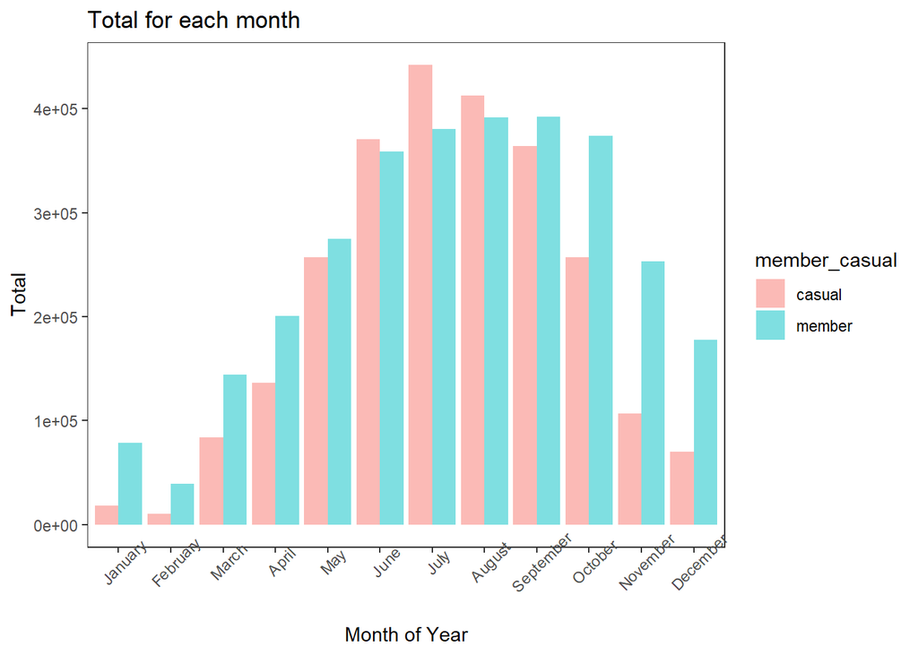

```r
usertype_df %>%
  ggplot(aes(x = ride_month1,  total_rides, fill = member_casual)) +
  geom_bar(position = "dodge", stat = "summary", fun = "sum",
           alpha = 0.5) +
  theme_bw() +
  theme(panel.grid.major = element_blank(),
        panel.grid.minor = element_blank()) +
  theme(axis.text.x = element_text(angle = 45)) +
  labs(title = "Total for each month",
       x = "Month of Year", y = "Total")
```

There is a trend of low figures from the beginning of the year which rises significantly and peaks towards the middle and falls again towards the end of the year.This pattern is visible for for both customer or user types with member users having higher patronage towards the end of the year.

#### AVERAGE RIDE DURATION FOR EACH MONTH

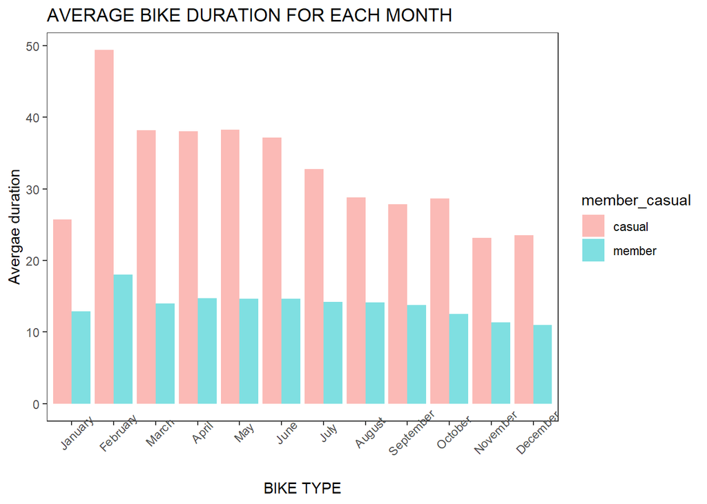

```r
usertype_df %>%
  ggplot(aes(x = ride_month1, avg_ride_duration, fill = member_casual)) +
  geom_bar(position = "dodge", stat = "summary", fun = "mean",
           alpha = 0.5) +
  theme_bw() +
  theme(panel.grid.major = element_blank(),
        panel.grid.minor = element_blank()) +
  theme(axis.text.x = element_text(angle = 45)) +
  labs(title = "AVERAGE BIKE DURATION FOR EACH MONTH",
       x = "BIKE TYPE", y = "Avergae duration")
```

Slightly higher average in February for member users and quiet consistent average ride duration for the entire year. Casual users also had a significantly high average in February and higher consistent averages for the subsequent months compared with Member users.

### DAY OF WEEK ANALYSIS FOR THE ENTIRE YEAR

```r
weekday_df <- read_csv("C:/Users/user/Desktop/Case Study/CASESTUDY CYCLING DATA/Cleaned Data/day_of_wee_for _wholeyear.csv")
head(weekday_df)
```

```
## # A tibble: 6 x 8
##   number_of_location number_of~1 avg_r~2 max_r~3 ridea~4 day_o~5 membe~6 max_r~7
##                <dbl>       <dbl>   <dbl>   <dbl> <chr>   <chr>   <chr>     <dbl>
## 1                674      307002    13.3   1500. classi~ Friday  member    25.0
## 2                711      137394    25.7   1500. classi~ Saturd~ casual    25.0
## 3              95339      145604    12.2    480. electr~ Wednes~ member     8.01
## 4                656       78435    80.6  55944. docked~ Monday  casual   932.
## 5             117861      178257    21.5    481. electr~ Monday  casual     8.01
## 6             107026      164637    12.6    481. electr~ Sunday  member     8.01
## # ... with abbreviated variable names 1: number_of_rides, 2: avg_ride_duration,
## #   3: max_ride_duration, 4: rideable_type, 5: day_of_week, 6: member_casual,
## #   7: max_ride_duration_hrs
```

#### Ordering the days of the week

```r
weekday_df$day_of_weekt <- factor(weekday_df$day_of_week, levels = c("Monday", "Tuesday", "Wednesday", "Thursday", "Friday", "Saturday", "Sunday"))
```

#### Total number of users for each Day of Week

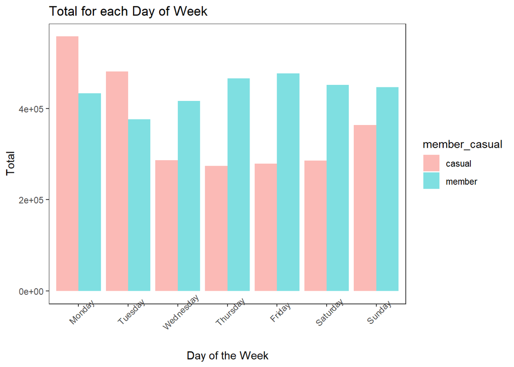

```r
weekday_df %>%
  ggplot(aes(x = day_of_weekt, number_of_rides, fill = member_casual)) +
  geom_bar(position = "dodge", stat = "summary", fun = "sum",
           alpha = 0.5) +
  theme_bw() +
  theme(panel.grid.major = element_blank(),
        panel.grid.minor = element_blank()) +
  theme(axis.text.x = element_text(angle = 45)) +
  labs(title = "Total for each Day of Week",
       x = "Day of the Week", y = "Total")
```

Member users show consistent patronage through out the week while casual users have highest patronage on Mondays and Tuesdays which gradually declines towards the weekend and starts to peak towards the beginning of the week

#### MAX RIDE DURATION FOR EACH DAY OF WEEK

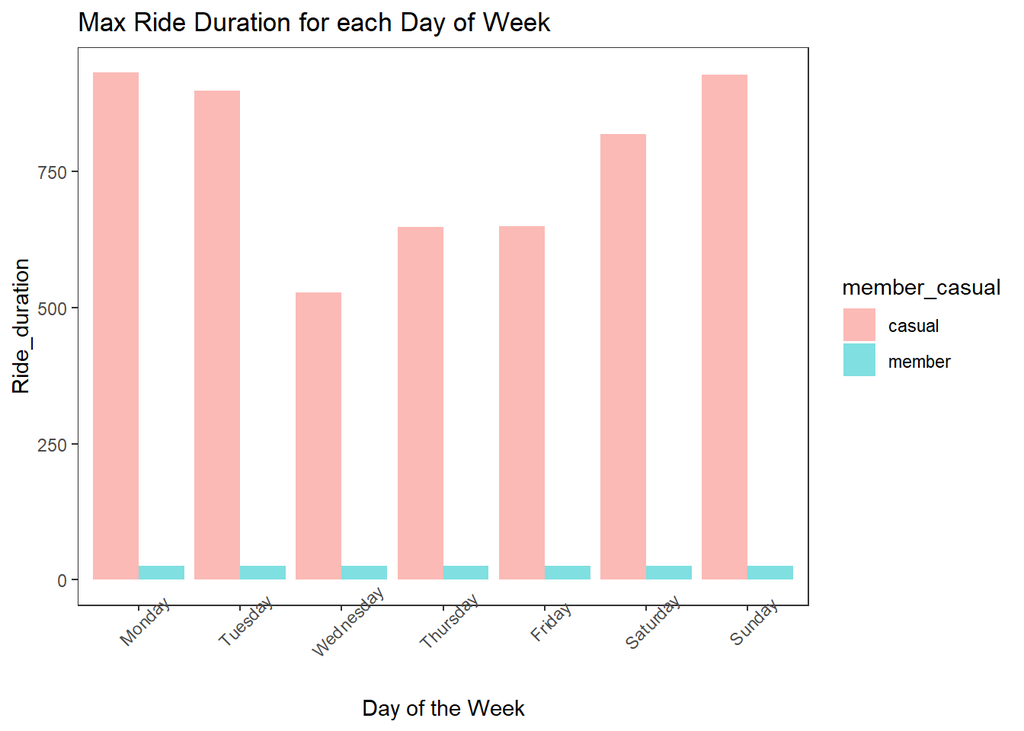

```r
weekday_df %>%
  ggplot(aes(x = day_of_weekt, max_ride_duration_hrs, fill = member_casual)) +
  geom_bar(position = "dodge", stat = "summary", fun = "max",
           alpha = 0.5) +
  theme_bw() +
  theme(panel.grid.major = element_blank(),
        panel.grid.minor = element_blank()) +
  theme(axis.text.x = element_text(angle = 45)) +
  labs(title = "Max Ride Duration for each Day of Week",
       x = "Day of the Week", y = "Ride_duration")
```

#### MAX RIDE DURATION WITHOUT DOCKED BIKES

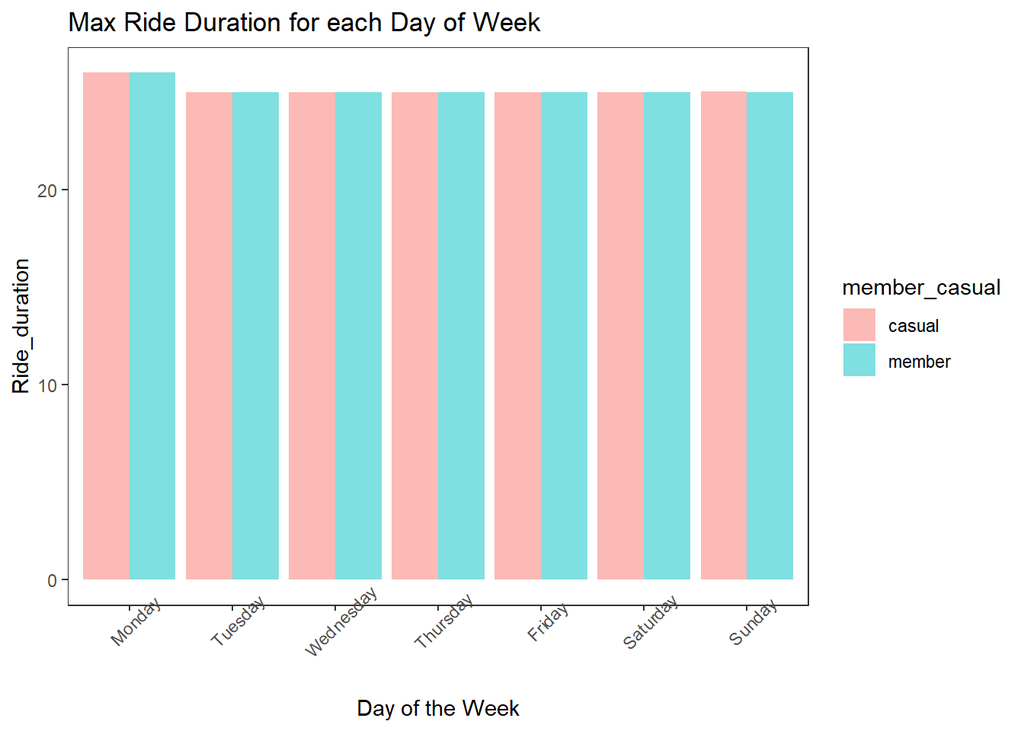

```r
weekday_df %>%
  filter(rideable_type == "classic_bike" |
           rideable_type == "electric_bike") %>%
  ggplot(aes(x = day_of_weekt, max_ride_duration_hrs,
             fill = member_casual)) +
  geom_bar(position = "dodge", stat = "summary", fun = "max",
           alpha = 0.5) +
  theme_bw() +
  theme(panel.grid.major = element_blank(),
        panel.grid.minor = element_blank()) +
  theme(axis.text.x = element_text(angle = 45)) +
  labs(title = "Max Ride Duration for each Day of Week",
       x = "Day of the Week", y = "Ride_duration")
```

With the exemption of Docked bike types we see equal duration trends highest Maximum durations and averages were solely influenced by Docked bike types

#### AERAGE RIDE DURATION FOR EACH DAY OF WEEK

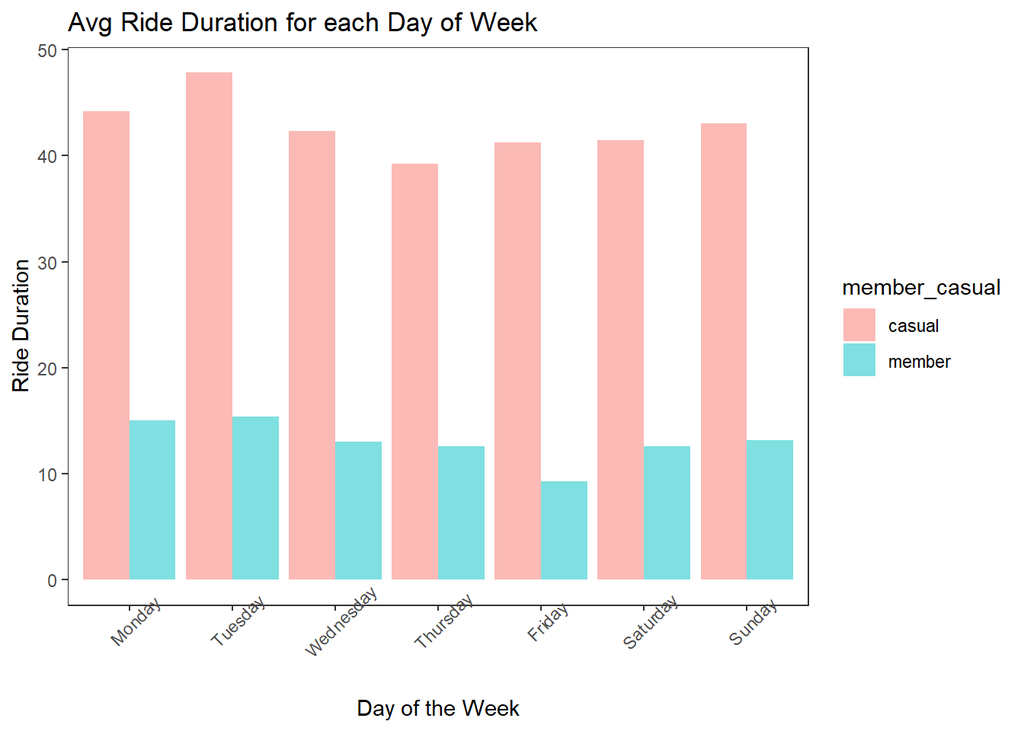

```r
weekday_df %>%
  ggplot(aes(x = day_of_weekt, avg_ride_duration,
             fill = member_casual)) +
  geom_bar(position = "dodge", stat = "summary", fun = "mean",
           alpha = 0.5) +
  theme_bw() +
  theme(panel.grid.major = element_blank(),
        panel.grid.minor = element_blank()) +
  theme(axis.text.x = element_text(angle = 45)) +
  labs(title = "Avg Ride Duration for each Day of Week",
       x = "Day of the Week", y = "Ride Duration")
```

Consistently significant difference in Averages with Casual users maintaining higher averages and Tuesdays recording the highest average.

#### AVERAGE RIDE DURATION FOR EACH WEEKDAY WITHOUT DOCKED BIKES

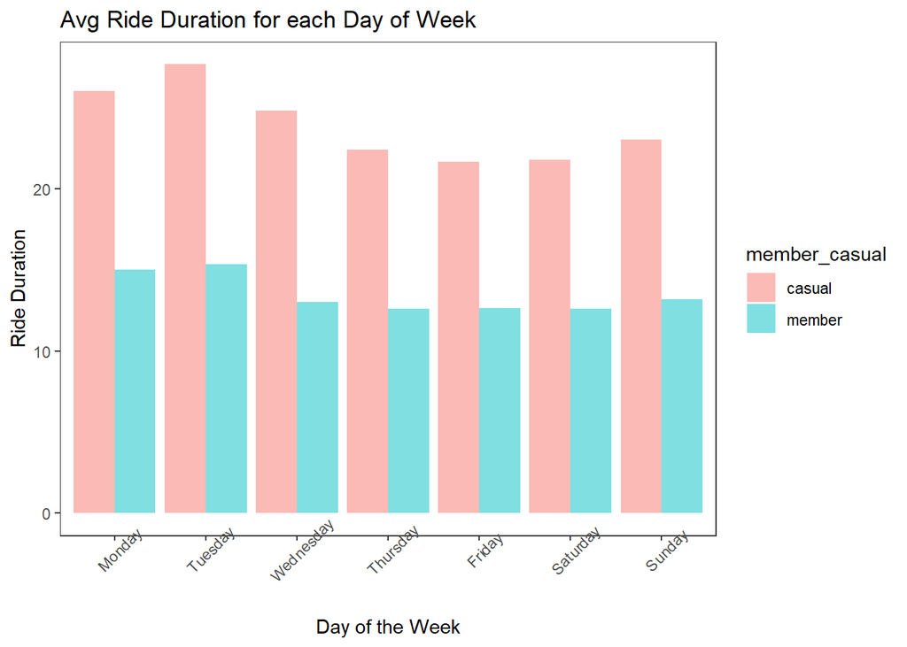

```r
weekday_df %>%
  filter(rideable_type == "classic_bike" |
           rideable_type == "electric_bike") %>%
  ggplot(aes(x = day_of_weekt, avg_ride_duration,
             fill = member_casual)) +
  geom_bar(position = "dodge", stat = "summary", fun = "mean",
           alpha = 0.5) +
  theme_bw() +
  theme(panel.grid.major = element_blank(),
        panel.grid.minor = element_blank()) +
  theme(axis.text.x = element_text(angle = 45)) +
  labs(title = "Avg Ride Duration for each Day of Week",
       x = "Day of the Week", y = "Ride Duration")
```

Higher averages for all days for casual users even without docked bike types which shows casual users ride bikes for longest distances.

#### BIKE TYPE PATRONAGE FOR THE YEAR

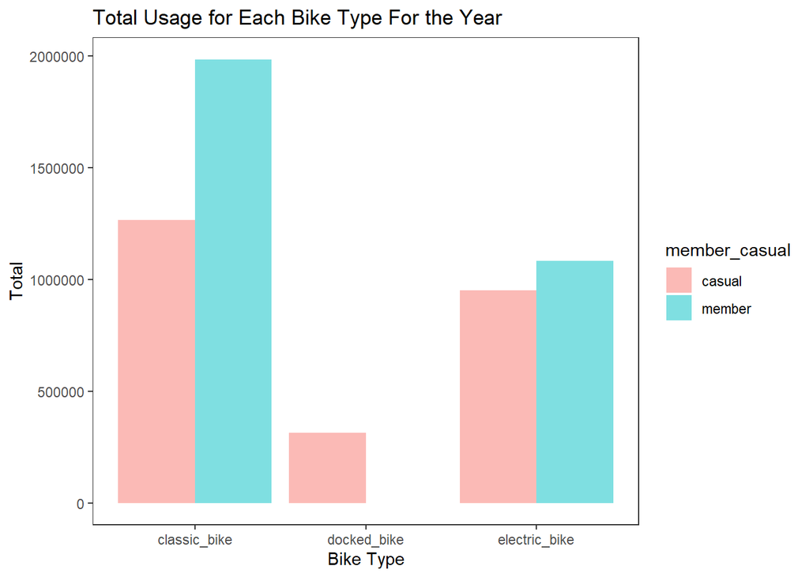

```r
weekday_df %>%
  ggplot(aes(x = rideable_type, number_of_rides, fill = member_casual)) +
  geom_bar(position = "dodge", stat = "summary", fun = "sum",
           alpha = 0.5) +
  theme_bw() +
  theme(panel.grid.major = element_blank(),
        panel.grid.minor = element_blank()) +
  labs(title = "Total Usage for Each Bike Type For the Year",
       x = "Bike Type", y = "Total")
```

Classic bike types had the highest usage for the entire year at 35.47% for member users and 22.64% for Casual users. Electric bike types were the next highly patronized bike type for Members and Casuals at 19.33% for Members and 16.98% for Casual users. Docked type bike were the least preferred with patronage only from Casual riders at 5.58%.

#### RIDE DURATION FOR EACH BIKE TYPE

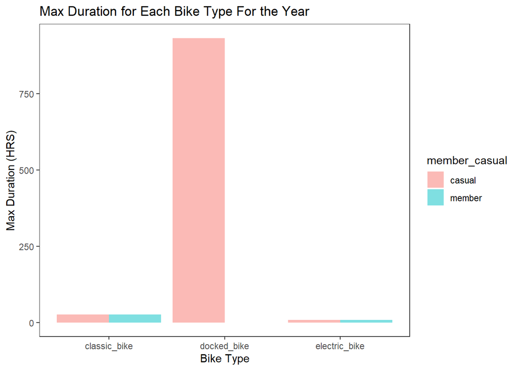

```r
weekday_df %>%
  ggplot(aes(x = rideable_type, max_ride_duration_hrs,
             fill = member_casual)) +
  geom_bar(position = "dodge", stat = "summary", fun = "max",
           alpha = 0.5) +
  theme_bw() +
  theme(panel.grid.major = element_blank(),
        panel.grid.minor = element_blank()) +
  labs(title = "Max Duration for Each Bike Type For the Year",
       x = "Bike Type", y = "Max Duration (HRS)")
```

Docked type bikes were ridden the longest distances while all other bike types showed similar average and maximum bike durations.

#### AVERAGE RIDE DURATION FOR EACH BIKE TYPE BASED ON CUSTOMER PATRONAGE

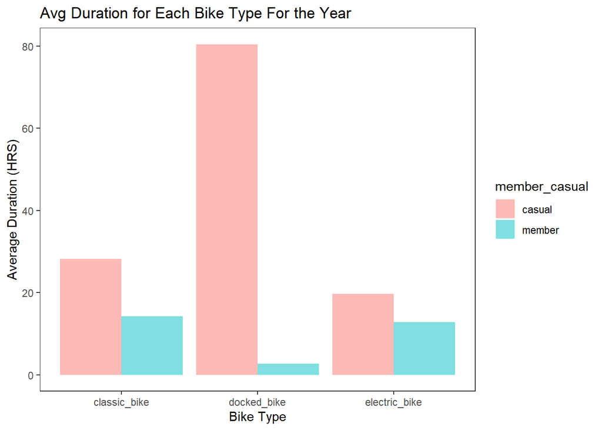

```r
weekday_df %>%
  ggplot(aes(x = rideable_type, avg_ride_duration,
             fill = member_casual)) +
  geom_bar(position = "dodge", stat = "summary", fun = "mean",
           alpha = 0.5) +
  theme_bw() +
  theme(panel.grid.major = element_blank(),
        panel.grid.minor = element_blank()) +
  labs(title = "Avg Duration for Each Bike Type For the Year",
       x = "Bike Type", y = "Average Duration (HRS)")
```

Casual users had the highest averages for different bike types with docked bike types having the longest ride distances and then classic bikes and the electric

#### TOTAL RIDES FOR EACH DAY OF WEEK FOR DIFFERENT CUSTOMER TYPES

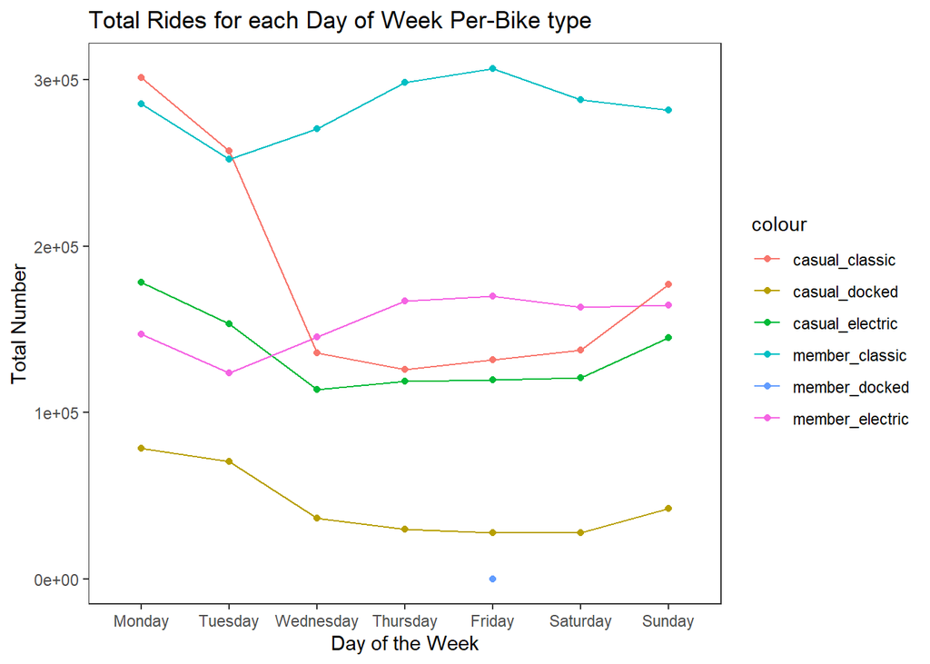

```r
df_ce <- weekday_df %>%
  filter(member_casual == "casual" & rideable_type == "electric_bike")
df_me <- weekday_df %>%
  filter(member_casual == "member" & rideable_type == "electric_bike")
df_cc <- weekday_df %>%
  filter(member_casual == "casual" & rideable_type == "classic_bike")
df_mc <- weekday_df %>%
  filter(member_casual == "member" & rideable_type == "classic_bike")
df_cd <- weekday_df %>%
  filter(member_casual == "casual" & rideable_type == "docked_bike")
df_md <- weekday_df %>%
  filter(member_casual == "member" & rideable_type == "docked_bike")

ggplot() +
  geom_line(data = df_ce, aes(x = day_of_weekt, y = number_of_rides, group = 1, color="casual_electric")) +
  geom_point(data = df_ce, aes(x = day_of_weekt, y = number_of_rides, color="casual_electric")) +
  geom_line(data = df_me, aes(x = day_of_weekt, y = number_of_rides, group = 1, color="member_electric")) +
  geom_point(data = df_me, aes(x = day_of_weekt, y = number_of_rides, color="member_electric")) +
  geom_line(data = df_cc, aes(x = day_of_weekt, y = number_of_rides, group = 1, color="casual_classic")) +
  geom_point(data = df_cc, aes(x = day_of_weekt, y = number_of_rides, color="casual_classic")) +
  geom_line(data = df_mc, aes(x = day_of_weekt, y = number_of_rides, group = 1, color="member_classic")) +
  geom_point(data = df_mc, aes(x = day_of_weekt, y = number_of_rides, color="member_classic")) +
  geom_line(data = df_cd, aes(x = day_of_weekt, y = number_of_rides, group = 1, color="casual_docked")) +
  geom_point(data = df_cd, aes(x = day_of_weekt, y = number_of_rides, color="casual_docked")) +
  geom_point(data = df_md, aes(x = day_of_weekt, y = number_of_rides, color="member_docked")) +
  theme_bw() +
  theme(panel.grid.major = element_blank(),
        panel.grid.minor = element_blank()) +
  labs(title = "Total Rides for each Day of Week Per-Bike type",
       x = "Day of the Week", y = "Total Number")
```

#### WEEKLY TRENDS FOR THE ENTIRE YEAR

```r
week_num <- read_csv("C:/Users/user/Desktop/Case Study/CASESTUDY CYCLING DATA/Cleaned Data/weekly_trends_wholeyear.csv")
head(week_num)
```

```
## # A tibble: 6 x 7
##   week_number number_of_rides avg_ride_duration max_ri~1 ridea~2 membe~3 max_r~4
##         <dbl>           <dbl>             <dbl>    <dbl> <chr>   <chr>     <dbl>
## 1           1             351              30.0    1457. classi~ casual     24.3
## 2           2            2474              24.4    1500. classi~ casual     25.0
## 3           3            2345              23.8    1500. classi~ casual     25.0
## 4           4            1797              25.1    1500. classi~ casual     25.0
## 5           5            1238              23.6    1500. classi~ casual     25.0
## 6           6             746              42.9    1500. classi~ casual     25.0
## # ... with abbreviated variable names 1: max_ride_duration, 2: rideable_type,
## #   3: member_casual, 4: `max_ride_duration (hrs)`
```

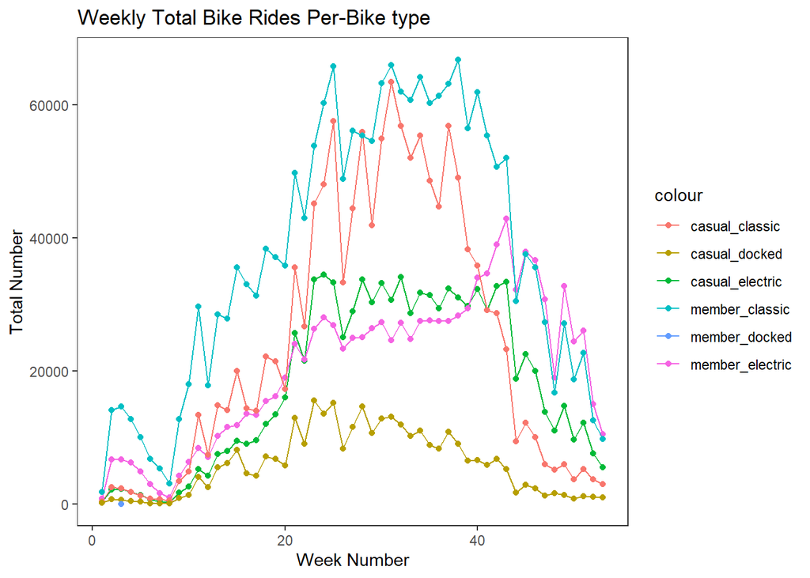

```r
df_ce1 <- week_num %>%
  filter(member_casual == "casual" & rideable_type == "electric_bike")
df_me1 <- week_num %>%
  filter(member_casual == "member" & rideable_type == "electric_bike")
df_cc1 <- week_num %>%
  filter(member_casual == "casual" & rideable_type == "classic_bike")
df_mc1 <- week_num %>%
  filter(member_casual == "member" & rideable_type == "classic_bike")
df_cd1 <- week_num %>%
  filter(member_casual == "casual" & rideable_type == "docked_bike")
df_md1 <- week_num %>%
  filter(member_casual == "member" & rideable_type == "docked_bike")

ggplot() +
  geom_line(data = df_ce1, aes(x = week_number, y = number_of_rides, group = 1, color="casual_electric")) +
  geom_point(data = df_ce1, aes(x = week_number, y = number_of_rides, color="casual_electric")) +
  geom_line(data = df_me1, aes(x = week_number, y = number_of_rides, group = 1, color="member_electric")) +
  geom_point(data = df_me1, aes(x = week_number, y = number_of_rides, color="member_electric")) +
  geom_line(data = df_cc1, aes(x = week_number, y = number_of_rides, group = 1, color="casual_classic")) +
  geom_point(data = df_cc1, aes(x = week_number, y = number_of_rides, color="casual_classic")) +
  geom_line(data = df_mc1, aes(x = week_number, y = number_of_rides, group = 1, color="member_classic")) +
  geom_point(data = df_mc1, aes(x = week_number, y = number_of_rides, color="member_classic")) +
  geom_line(data = df_cd1, aes(x = week_number, y = number_of_rides, group = 1, color="casual_docked")) +
  geom_point(data = df_cd1, aes(x = week_number, y = number_of_rides, color="casual_docked")) +
  geom_point(data = df_md1, aes(x = week_number, y = number_of_rides, color="member_docked")) +
  theme_bw() +
  theme(panel.grid.major = element_blank(),
        panel.grid.minor = element_blank()) +
  labs(title = "Weekly Total Bike Rides Per-Bike type",
       x = "Week Number", y = "Total Number")
```

### WEEKLY TRENDS FOR THE ENTIRE YEAR

```r
week_num <- read_csv("C:/Users/user/Desktop/Case Study/CASESTUDY CYCLING DATA/Cleaned Data/weekly_trends_wholeyear.csv")
head(week_num)
```

```
## # A tibble: 6 x 7
##   week_number number_of_rides avg_ride_duration max_ri~1 ridea~2 membe~3 max_r~4
##         <dbl>           <dbl>             <dbl>    <dbl> <chr>   <chr>     <dbl>
## 1           1             351              30.0    1457. classi~ casual     24.3
## 2           2            2474              24.4    1500. classi~ casual     25.0
## 3           3            2345              23.8    1500. classi~ casual     25.0
## 4           4            1797              25.1    1500. classi~ casual     25.0
## 5           5            1238              23.6    1500. classi~ casual     25.0
## 6           6             746              42.9    1500. classi~ casual     25.0
## # ... with abbreviated variable names 1: max_ride_duration, 2: rideable_type,
## #   3: member_casual, 4: `max_ride_duration (hrs)`
```

#### Weekly Total Bike Rides Per-Bike type

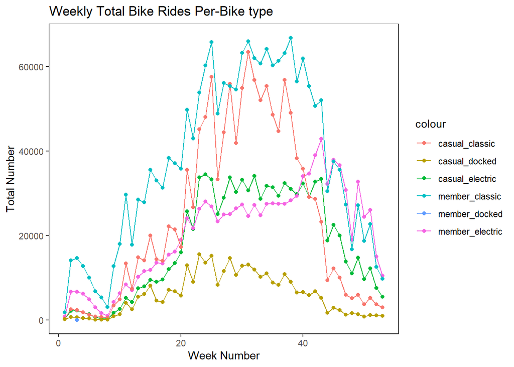

```r
df_ce1 <- week_num %>%
  filter(member_casual == "casual" & rideable_type == "electric_bike")
df_me1 <- week_num %>%
  filter(member_casual == "member" & rideable_type == "electric_bike")
df_cc1 <- week_num %>%
  filter(member_casual == "casual" & rideable_type == "classic_bike")
df_mc1 <- week_num %>%
  filter(member_casual == "member" & rideable_type == "classic_bike")
df_cd1 <- week_num %>%
  filter(member_casual == "casual" & rideable_type == "docked_bike")
df_md1 <- week_num %>%
  filter(member_casual == "member" & rideable_type == "docked_bike")

ggplot() +
  geom_line(data = df_ce1, aes(x = week_number, y = number_of_rides, group = 1, color="casual_electric")) +
  geom_point(data = df_ce1, aes(x = week_number, y = number_of_rides, color="casual_electric")) +
  geom_line(data = df_me1, aes(x = week_number, y = number_of_rides, group = 1, color="member_electric")) +
  geom_point(data = df_me1, aes(x = week_number, y = number_of_rides, color="member_electric")) +
  geom_line(data = df_cc1, aes(x = week_number, y = number_of_rides, group = 1, color="casual_classic")) +
  geom_point(data = df_cc1, aes(x = week_number, y = number_of_rides, color="casual_classic")) +
  geom_line(data = df_mc1, aes(x = week_number, y = number_of_rides, group = 1, color="member_classic")) +
  geom_point(data = df_mc1, aes(x = week_number, y = number_of_rides, color="member_classic")) +
  geom_line(data = df_cd1, aes(x = week_number, y = number_of_rides, group = 1, color="casual_docked")) +
  geom_point(data = df_cd1, aes(x = week_number, y = number_of_rides, color="casual_docked")) +
  geom_point(data = df_md1, aes(x = week_number, y = number_of_rides, color="member_docked")) +
  theme_bw() +
  theme(panel.grid.major = element_blank(),
        panel.grid.minor = element_blank()) +
  labs(title = "Weekly Total Bike Rides Per-Bike type",
       x = "Week Number", y = "Total Number")
```

#### AVERAGE RIDE DURATION TRENDS FOR THE YEAR

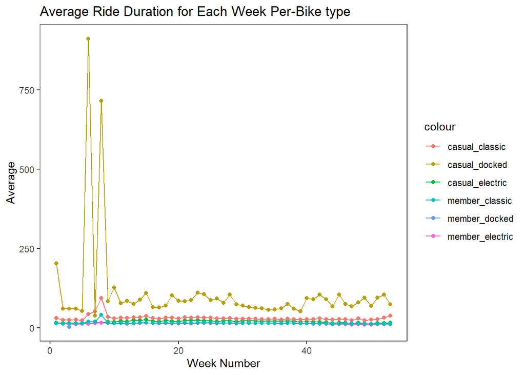

```r
ggplot() +
  geom_line(data = df_ce1, aes(x = week_number, y = avg_ride_duration, group = 1, color="casual_electric")) +
  geom_point(data = df_ce1, aes(x = week_number, y = avg_ride_duration, color="casual_electric")) +
  geom_line(data = df_me1, aes(x = week_number, y = avg_ride_duration, group = 1, color="member_electric")) +
  geom_point(data = df_me1, aes(x = week_number, y = avg_ride_duration, color="member_electric")) +
  geom_line(data = df_cc1, aes(x = week_number, y = avg_ride_duration, group = 1, color="casual_classic")) +
  geom_point(data = df_cc1, aes(x = week_number, y = avg_ride_duration, color="casual_classic")) +
  geom_line(data = df_mc1, aes(x = week_number, y = avg_ride_duration, group = 1, color="member_classic")) +
  geom_point(data = df_mc1, aes(x = week_number, y = avg_ride_duration, color="member_classic")) +
  geom_line(data = df_cd1, aes(x = week_number, y = avg_ride_duration, group = 1, color="casual_docked")) +
  geom_point(data = df_cd1, aes(x = week_number, y = avg_ride_duration, color="casual_docked")) +
  geom_point(data = df_md1, aes(x = week_number, y = avg_ride_duration, color="member_docked")) +
  theme_bw() +
  theme(panel.grid.major = element_blank(),
        panel.grid.minor = element_blank()) +
  labs(title = "Average Ride Duration for Each Week Per-Bike type",
       x = "Week Number", y = "Average")
```

Docked type bikes were driven the longest distances while all other bike types showed similar average and maximum bike durations.

#### TOTAL USAGE FOR EACH WEEK FOR EACH CUSTOMER TYPE

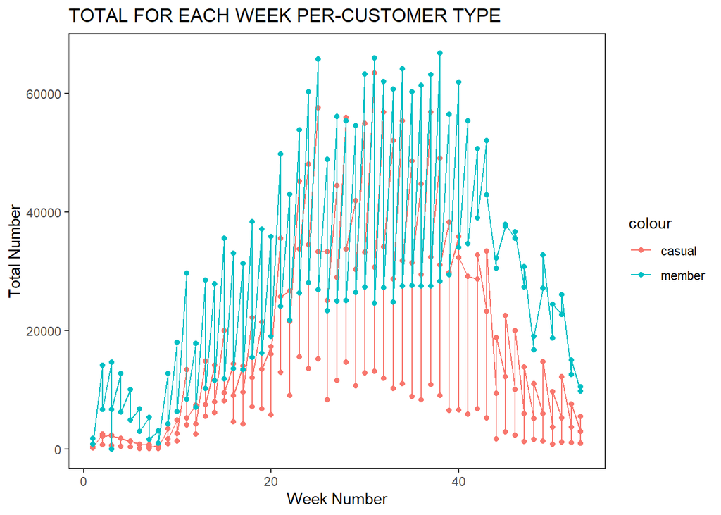

```r
df_y1 <- week_num %>%
  filter(member_casual == "casual")
df_y2 <- week_num %>%
  filter(member_casual == "member")

ggplot() +
  geom_line(data = df_y1, aes(x = week_number, y = number_of_rides, group = 1, color="casual")) +
  geom_point(data = df_y1, aes(x = week_number, y = number_of_rides, color="casual")) +
  geom_line(data = df_y2, aes(x = week_number, y = number_of_rides, group = 1, color="member")) +
  geom_point(data = df_y2, aes(x = week_number, y = number_of_rides, color="member")) +
  theme_bw() +
  theme(panel.grid.major = element_blank(),
        panel.grid.minor = element_blank()) +
  labs(title = "TOTAL FOR EACH WEEK PER-CUSTOMER TYPE",
       x = "Week Number", y = "Total Number")
```

Casual users show very low patronage in the beginning of the year which peaks and picks up and gradually goes back down at the end of the year.

### SUMMARY

#### AVERAGE BIKE DURATION

Average ride duration for casual users for the year was 32.61 while members recorded 13.81.

The average ride duration is fairly consistent throughout the year with Casual riders recording significantly high averages.

#### MAX RIDE DURATION

The highest recorded maximum ride duration was 932 hours for Casual users and 25.99 for member users for the entire year.

Docked bike types had the maximum ride duration for the entire year by Casual users.

#### MONTHLY DATA

There is a trend of low figures from the beginning of the year which rises significantly and peaks towards the middle and falls again towards the end of the year.

#### WEEKLY BIKE USAGE

Highest averages on the 6th and 8th week respectively for causal riders but the other weeks maintain significantly higher consistent averages compared to Member averages which were fairly consistent throughout the weeks.

### RIDEABLE TYPE (BIKE TYPE) ANALYSIS

Classic bike types had the highest usage for the entire year at 35.47% for member users and 22.64% for Casual users.

Electric bike types were the next highly patronized bike type for Members and Casuals at 19.33% for Members and 16.98% for Casual users. Patronage increasing above classic bike types towards the end of the year.

Docked type bike were the least preferred with patronage only from Casual riders at 5.58%.

Docked type bikes were driven the longest distances while all other bike types showed similar average and maximum bike durations.